# Time series regression

Author

Patrick A. Singleton

### Objectives & outcomes

The objectives of this tutorial are to:

- Understand what a time series is.
- Understand what the components of a time series are.
- Learn how to decompose a time series into components.
- Practice doing basic multivariate time series regression.

At the end of this tutorial, you should be able to:

- Create and plot a univariate time series.
- Decompose a time series into seasonal, trend, and error components.
- Estimate a linear time series regression model.

### Transportation dataset

For this tutorial, we will use data from the *Logan non-motorized trail count data* project. The datasets include information on daily counts of non-motorized (walking and bicycling) traffic at two locations: along the Boulevard Trail in Logan (*Boulevard*), and along a trail in Green Canyon (*GreenCanyon*). There are also weather (*Weather*) and air quality (*AirQuality*) data for the same dates. You can access these data from the [Transportation datasets](https://github.com/singletonpa/usu-course-transport-data-research/blob/main/Data/Transportation_datasets.md) page on GitHub.

```r
# Load data from GitHub
Boulevard <- read.csv(file=url("https://raw.github.com/singletonpa/usu-course-transport-data-safety/main/Data/Logan_trail_counts/Boulevard.csv", method="libcurl"))
GreenCanyon <- read.csv(file=url("https://raw.github.com/singletonpa/usu-course-transport-data-safety/main/Data/Logan_trail_counts/GreenCanyon.csv", method="libcurl"))
Weather <- read.csv(file=url("https://raw.github.com/singletonpa/usu-course-transport-data-safety/main/Data/Logan_trail_counts/Weather.csv", method="libcurl"))
AirQuality <- read.csv(file=url("https://raw.github.com/singletonpa/usu-course-transport-data-safety/main/Data/Logan_trail_counts/AirQuality.csv", method="libcurl"))

# Rename columns
names(Boulevard) <- c("Date", "CountBL")
names(GreenCanyon) <- c("Date", "CountGC")

# Merging data together using common column "Date"
dat <- merge(Boulevard, GreenCanyon, by="Date", all.x=T, all.y=T)
dat <- merge(dat, Weather, by="Date", all.x=T, all.y=T)
dat <- merge(dat, AirQuality, by="Date", all.x=T, all.y=T)

# Format date
dat$Date <- as.Date(dat$Date, format="%Y-%m-%d")

# Extract other info from date
dat$Year <- strftime(dat$Date, format="%Y")
dat$Month <- strftime(dat$Date, format="%m")
dat$Weekday <- strftime(dat$Date, format="%a")

# Convert text to factor
dat$Year <- factor(dat$Year, levels=c("2018", "2019"))
dat$Month <- factor(dat$Month, levels=c("01", "02", "03", "04", "05", "06", "07", "08", "09", "10", "11", "12"),
    labels=c("Jan", "Feb", "Mar", "Apr", "May", "Jun", "Jul", "Aug", "Sep", "Oct", "Nov", "Dec"))
dat$Weekday <- factor(dat$Weekday, levels=c("Mon", "Tue", "Wed", "Thu", "Fri", "Sat", "Sun"))

# Inspect
str(dat)
```

```
'data.frame':   730 obs. of  22 variables:
 $ Date                  : Date, format: "2018-01-01" "2018-01-02" ...
 $ CountBL               : num  92 104 93 85 116 59 78 138 101 153 ...
 $ CountGC               : num  134 46 37 30 39 87 69 42 26 14 ...
 $ Precipitation         : num  0 0 0 0 0 0 0.26 0 0.08 0.31 ...
 $ Snow                  : num  0 0 0 0 0 0 2 0 0 0 ...
 $ Snowdepth_WE          : num  3 3 3 3 3 ...
 $ Temp_Max              : num  30 34 30 31 39 40 32 34 37 45 ...
 $ Temp_Min              : num  15 16 13 13 15 24 26 22 21 32 ...
 $ HourlyRelativeHumidity: num  66.9 70.1 70.9 68 67 ...
 $ HourlyWindSpeed       : num  1.25 0.69 0.952 0.393 1.708 ...
 $ AQI                   : int  53 60 74 95 120 96 73 44 51 39 ...
 $ Ozone_AQI             : num  30 29 22 24 20 19 23 22 19 39 ...
 $ PM10_AQI              : num  17 21 27 37 50 33 19 10 14 4 ...
 $ PM25_AQI              : int  53 60 74 95 120 96 73 44 51 8 ...
 $ NO2_AQI               : num  27 32 28 28 38 26 18 17 17 13 ...
 $ Ozone                 : num  0.032 0.031 0.024 0.026 0.022 0.02 0.025 0.024 0.02 0.042 ...
 $ PM10                  : num  18 22.5 29 40 54 36 20 11 15 4 ...
 $ PM25                  : num  12.6 14.2 22.3 29.4 40 ...
 $ NO2                   : num  29 34 30 30 40 28 19 18 18 14 ...
 $ Year                  : Factor w/ 2 levels "2018","2019": 1 1 1 1 1 1 1 1 1 1 ...
 $ Month                 : Factor w/ 12 levels "Jan","Feb","Mar",..: 1 1 1 1 1 1 1 1 1 1 ...
 $ Weekday               : Factor w/ 7 levels "Mon","Tue","Wed",..: 1 2 3 4 5 6 7 1 2 3 ...
```

```python
# Load modules
import pandas as pd
import numpy as np

# Changing setting until pandas 3.0
pd.options.mode.copy_on_write = True

# Load data from GitHub
Boulevard = pd.read_csv("https://raw.github.com/singletonpa/usu-course-transport-data-safety/main/Data/Logan_trail_counts/Boulevard.csv")
GreenCanyon = pd.read_csv("https://raw.github.com/singletonpa/usu-course-transport-data-safety/main/Data/Logan_trail_counts/GreenCanyon.csv")
Weather = pd.read_csv("https://raw.github.com/singletonpa/usu-course-transport-data-safety/main/Data/Logan_trail_counts/Weather.csv")
AirQuality = pd.read_csv("https://raw.github.com/singletonpa/usu-course-transport-data-safety/main/Data/Logan_trail_counts/AirQuality.csv")

# Rename columns
Boulevard.rename(columns={'Count':'CountBL'}, inplace=True)
GreenCanyon.rename(columns={'Count':'CountGC'}, inplace=True)

# Merging data together using common column 'Date'
dat = pd.merge(Boulevard, GreenCanyon, on='Date', how='outer')
dat = pd.merge(dat, Weather, on='Date', how='outer')
dat = pd.merge(dat, AirQuality, on='Date', how='outer')

# Format date
dat['Date'] = pd.to_datetime(dat['Date'], format='%Y-%m-%d')

# Extract other info from date
dat['Year'] = dat['Date'].dt.strftime('%Y')
dat['Month'] = dat['Date'].dt.strftime('%b')
dat['Weekday'] = dat['Date'].dt.strftime('%a')

# Convert text to factor
dat['Year'] = dat['Year'].astype('category')
month_labels = ["Jan", "Feb", "Mar", "Apr", "May", "Jun",
                "Jul", "Aug", "Sep", "Oct", "Nov", "Dec"]
dat['Month'] = pd.Categorical(dat['Month'], categories=month_labels)
weekday_labels = ["Mon", "Tue", "Wed", "Thu", "Fri", "Sat", "Sun"]
dat['Weekday'] = pd.Categorical(dat['Weekday'], categories=weekday_labels)
del month_labels, weekday_labels

# Inspect
dat.info()
```

```
<class 'pandas.core.frame.DataFrame'>
RangeIndex: 730 entries, 0 to 729
Data columns (total 22 columns):
 #   Column                  Non-Null Count  Dtype
---  ------                  --------------  -----
 0   Date                    730 non-null    datetime64[ns]
 1   CountBL                 730 non-null    float64
 2   CountGC                 730 non-null    float64
 3   Precipitation           730 non-null    float64
 4   Snow                    730 non-null    float64
 5   Snowdepth_WE            730 non-null    float64
 6   Temp_Max                730 non-null    float64
 7   Temp_Min                730 non-null    float64
 8   HourlyRelativeHumidity  730 non-null    float64
 9   HourlyWindSpeed         730 non-null    float64
 10  AQI                     730 non-null    int64
 11  Ozone_AQI               730 non-null    float64
 12  PM10_AQI                730 non-null    float64
 13  PM25_AQI                730 non-null    int64
 14  NO2_AQI                 730 non-null    float64
 15  Ozone                   730 non-null    float64
 16  PM10                    730 non-null    float64
 17  PM25                    730 non-null    float64
 18  NO2                     730 non-null    float64
 19  Year                    730 non-null    category
 20  Month                   730 non-null    category
 21  Weekday                 730 non-null    category
dtypes: category(3), datetime64[ns](1), float64(16), int64(2)
memory usage: 111.5 KB
```

## Time series fundamentals

A **time series** is basically a sequence of repeated observations of the same variable over time. Time series data tell us valuable information about how a variable changes over time, and through regression we can examine systematic variations and associations with other factors that also change over time. For example, we may want to examine the relationship between temperature and bicycling, or the effect of a transit fare increase on public transit ridership.

There is a special *time series* object in R that is either a vector (one dimension) or matrix (two dimensions) of data measured at multiple, equal-spaced time intervals. We can create a time series using the `ts()` function:

```r
# Create a time series
myts <- ts(dat$CountBL)
str(myts)
```

```
 Time-Series [1:730] from 1 to 730: 92 104 93 85 116 59 78 138 101 153 ...
```

```r
head(myts,100)
```

```
Time Series:
Start = 1
End = 100
Frequency = 1
  [1]  92 104  93  85 116  59  78 138 101 153 133 179 214 184 198 179 198 179
 [19] 103  75 132 136 166 140 101 120 118 125 214 204 155 197 183 209 138 165
 [37] 189 156 208 218 185 158 188 197 157 152 123 167  41  50 109 118 103  79
 [55]  69  73 131 118 138 137 111  94  65  87 158 110 132 108 200 215 321 303
 [73] 145 113 256  85 166 222 243 181 152 200 169  68 186 280 241 275 221 176
 [91] 286 113 239 212 215 139 159 155 327 316
```

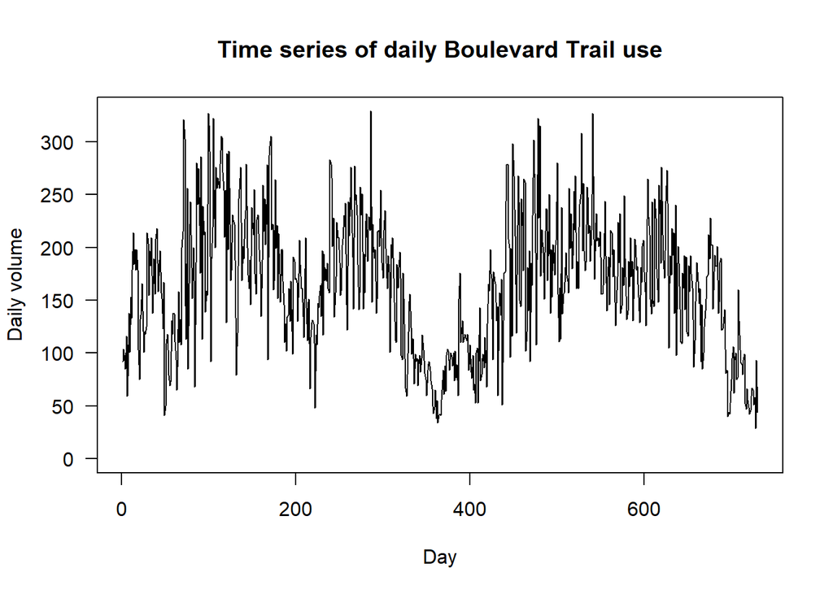

```r
plot(myts, ylim=c(0, max(dat$CountBL)), las=1,
  xlab="Day", ylab="Daily volume",
  main="Time series of daily Boulevard Trail use")
```

If we have data that exhibit repetitive patterns over time (such as by hour of the day, day of the week, or month of the year), we can specify a frequency by which the data repeat. For example, we can plot our observations over weeks:

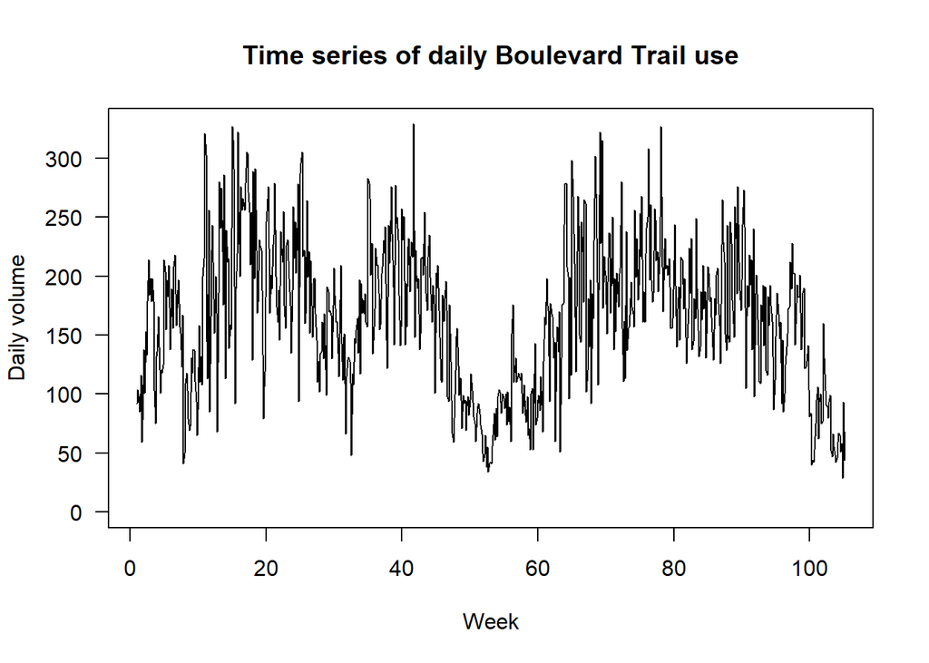

```r
# Create a time series
myts <- ts(dat$CountBL, frequency=7)
plot(myts, ylim=c(0, max(dat$CountBL)), las=1,
  xlab="Week", ylab="Daily volume",
  main="Time series of daily Boulevard Trail use")
```

Alternatively, we could have specified the week of the year:

```r
# Create a time series (not run)
myweek <- as.numeric(format(dat$Date[1], format="%U")) # gets week of year, 1=first sunday
myweekday <- as.numeric(format(dat$Date[1], format="%w")) # get day of week, 0=sunday
myts <- ts(dat$CountBL, start=c(myweek, myweekday), frequency=7)
plot(myts, ylim=c(0, max(dat$CountBL)), las=1,
  xlab="Week", ylab="Daily volume",
  main="Time series of daily Boulevard Trail use")
```

If we have a very long time series, we could even specify the day of the year:

```r
# Create a time series (not run)
myyear <- as.numeric(format(dat$Date[1], format="%Y")) # get year
myyearday <- as.numeric(format(dat$Date[1], format="%j")) # get day of year, 1=jan 1st
myts <- ts(dat$CountBL, start=c(myyear, myyearday), frequency=365.25)
plot(myts, ylim=c(0, max(dat$CountBL)), las=1,
  xlab="Day of Year", ylab="Daily volume",
  main="Time series of daily Boulevard Trail use")
```

However, the proper way to represent a multi-year daily time series is probably by specifying both weekly and annual periods. We can do this with the `msts()` function from the `forecast` package:

```r
# install.packages("forecast")
library("forecast")
# Create a time series (not run)
myts <- msts(dat$CountBL, seasonal.periods=c(7, 365.25), start=c(myyear, myyearday))
str(myts)
head(myts, 100)
plot(myts, ylim=c(0, max(dat$CountBL)), las=1,
  ylab="Daily volume",
  main="Time series of daily Boulevard Trail use")
```

No matter what we do, this should look identical to a simple scatterplot of our data over time:

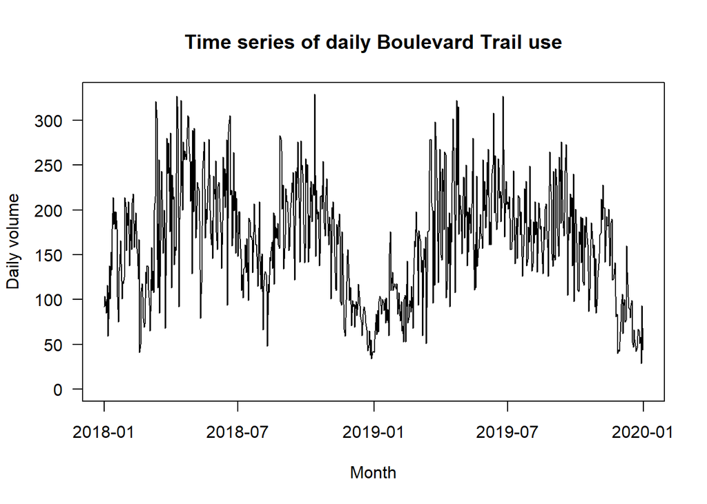

```r
plot(dat$Date, dat$CountBL,
  ylim=c(0, max(dat$CountBL)), las=1, type="l",
  xlab="Month", ylab="Daily volume",
  main="Time series of daily Boulevard Trail use")
```

In Python, you can create a *time series* object that is either a series (one dimension) or a dataframe (two dimensions) of data measured at multiple, equal-spaced time intervals. We can create a daily time series using the `date_range()` function, specify the frequency as daily (`freq='D'`), and setting the index of a series or dataframe to the time units.

```python
# Create a time series
first_date = pd.to_datetime(dat["Date"].iloc[0])
myweek = int(first_date.strftime("%U"))  # Week number (Sunday as first day)
myweekday = int(first_date.strftime("%w"))  # Day of week (0=Sunday)
ts_index = pd.date_range(start=first_date, periods=len(dat), freq='D')
myts = pd.Series(dat["CountBL"].values, index=ts_index)
del first_date, myweek, myweekday

# Inspect
myts
```

```
2018-01-01     92.0
2018-01-02    104.0
2018-01-03     93.0
2018-01-04     85.0
2018-01-05    116.0
              ...
2019-12-27     51.0
2019-12-28     58.0
2019-12-29     29.0
2019-12-30     93.0
2019-12-31     44.0
Freq: D, Length: 730, dtype: float64
```

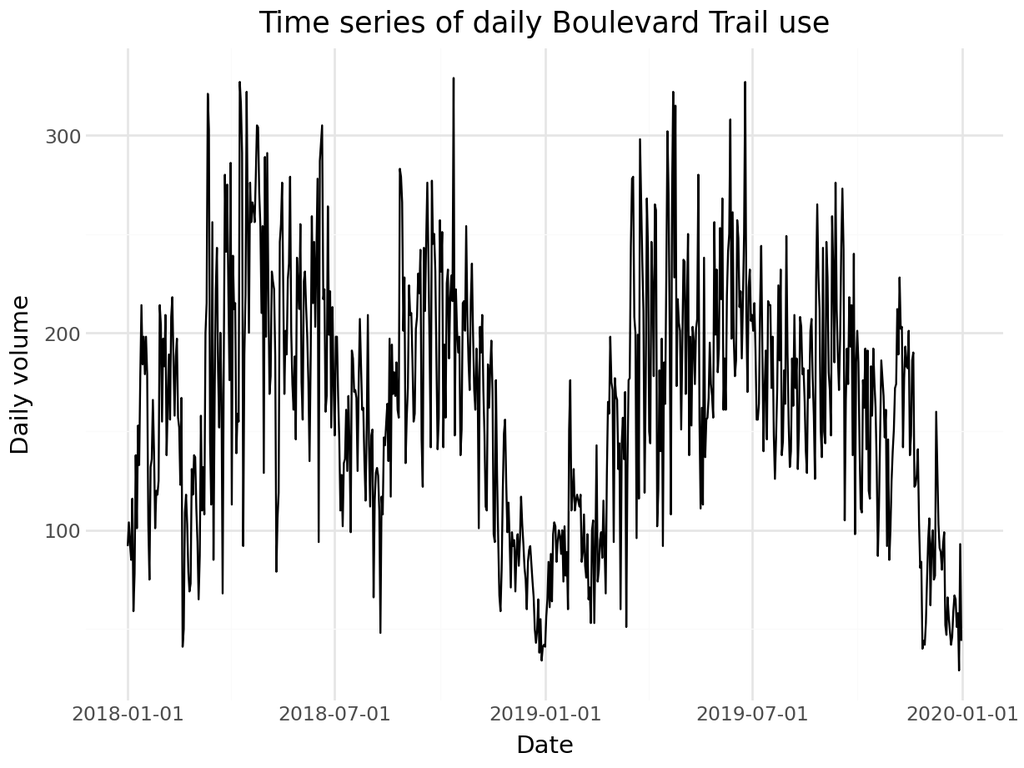

```python
# Load packages
import plotnine as p9

# Plot time series
temp = pd.DataFrame({"CountBL":myts, "Date":myts.index})
(p9.ggplot(temp, p9.aes(x="Date", y="CountBL")) +
  p9.geom_line() +
  p9.labs(x="Date", y="Daily volume",
    title = "Time series of daily Boulevard Trail use") +
  p9.theme_minimal()
  ).show()
```

This should look identical to a simple scatterplot of our data over time:

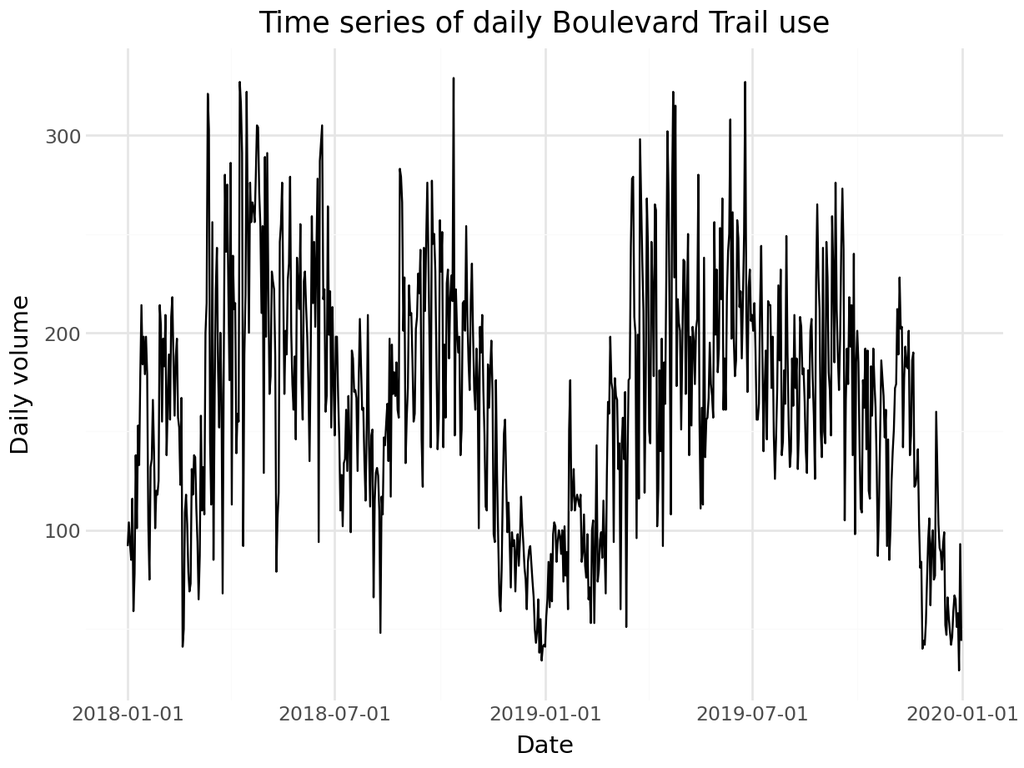

```python
del temp

(p9.ggplot(dat, p9.aes(x="Date", y="CountBL")) +
  p9.geom_line() +
  p9.labs(x="Date", y="Daily volume",
    title = "Time series of daily Boulevard Trail use") +
  p9.theme_minimal()
  ).show()
```

### Time series components

Traditional analyses of time series data assume that we can break up the values of a time series $Y_t = f(T_t, S_t, E_t)$ into three components: a *trend component $T_t$*, a *seasonal component $S_t$*, and an *irregular (or random) component $E_t$*.

- The **trend component $T_t$** in a time series is a long-term change, movement, or direction in the dataset. In some cases, time series analyses involve removing the trend to reveal an underlying periodic component. The assumption is that the underlying trend is less important (or unimportant) than the seasonal component or relationship under study. In other cases, we are more interested in the long-term trend and just want to control for the seasonal component.
- The **seasonal component $S_t$** in a time series is a shorter-term pattern that repeats within a constant time period. Although this is called a “seasonal” pattern, it really refers to any representative temporal pattern. Depending on the time analyzed, the seasonal component of traffic count data could be the patterns over the hours of a day, days of a week, or months of a year.
- The **irregular (random) component $E_t$** is the remainder (i.e., error or residual) of the time series after removing trend and seasonal components.

These trends often interact **additively ($Y_t = T_t + S_t + E_t$)**, when the seasonal component is constant over the series. Other times, when the seasonal component increases (or decreases) with the level of the series, the components may interact **multiplicatively ($Y_t = T_t \times S_t \times E_t$)**; but this can be represented linearly using transformations ($ln(Y_t) = ln(T_t) + ln(S_t) + ln(E_t)$).

In R, there are a few ways of **filtering** or removing the *trend component* from the data. Removing the trend often helps to illuminate the seasonal component or relationship that is being studied. For example, if you are studying the relationship between weather and traffic volumes, you likely want to remove any long-term increase in traffic due to general population increases in the region. Let’s briefly look at two methods to do this:

- The [loess method](https://en.wikipedia.org/wiki/Local_regression), a form of smoothing filter, decomposes a time series into components.
- The [moving averages](https://en.wikipedia.org/wiki/Moving-average_model) method also decomposes a times series into components.

Let’s take a look at these methods and their results. For now, let’s just assume additive (not multiplicative) components.

In R, you can use the `stl()` function for the loess method, and the `decompose()` function for the moving averages method.

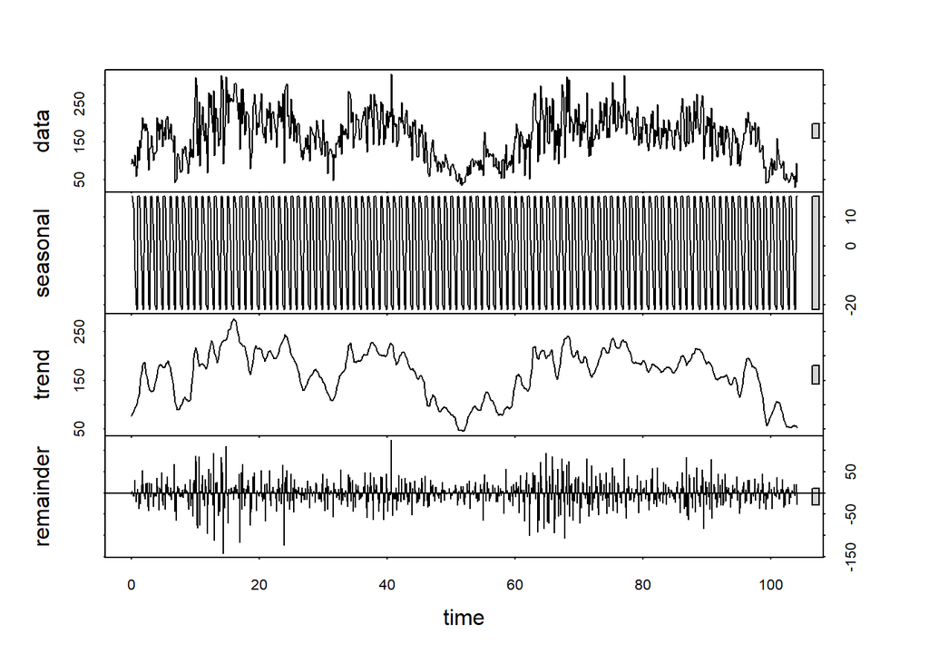

```r
# Create a time series
myweek <- as.numeric(format(dat$Date[1], format="%U")) # gets week of year, 1=first sunday
myweekday <- as.numeric(format(dat$Date[1], format="%w")) # get day of week, 0=sunday
myts <- ts(dat$CountBL, start=c(myweek, myweekday), frequency=7)

# Time series seasonal decomposition
# using stl()
myts_decomp1 <- stl(myts, s.window="periodic")
plot(myts_decomp1)
```

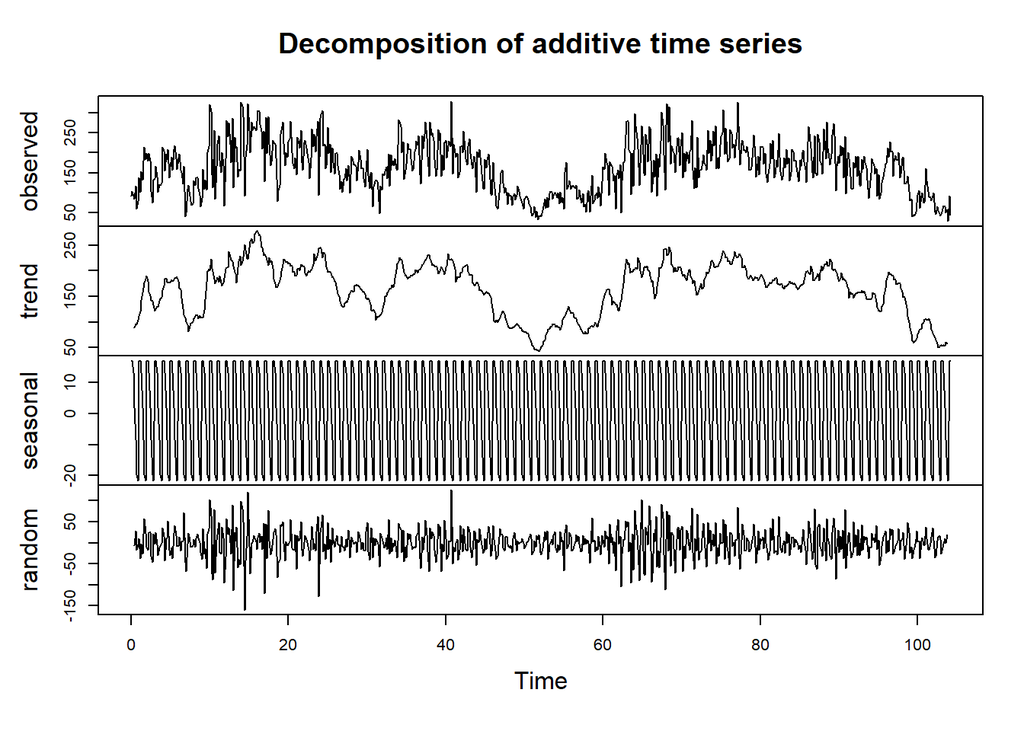

```r
# using decompose() & additive components
myts_decomp2 <- decompose(myts, type="additive")
plot(myts_decomp2)
```

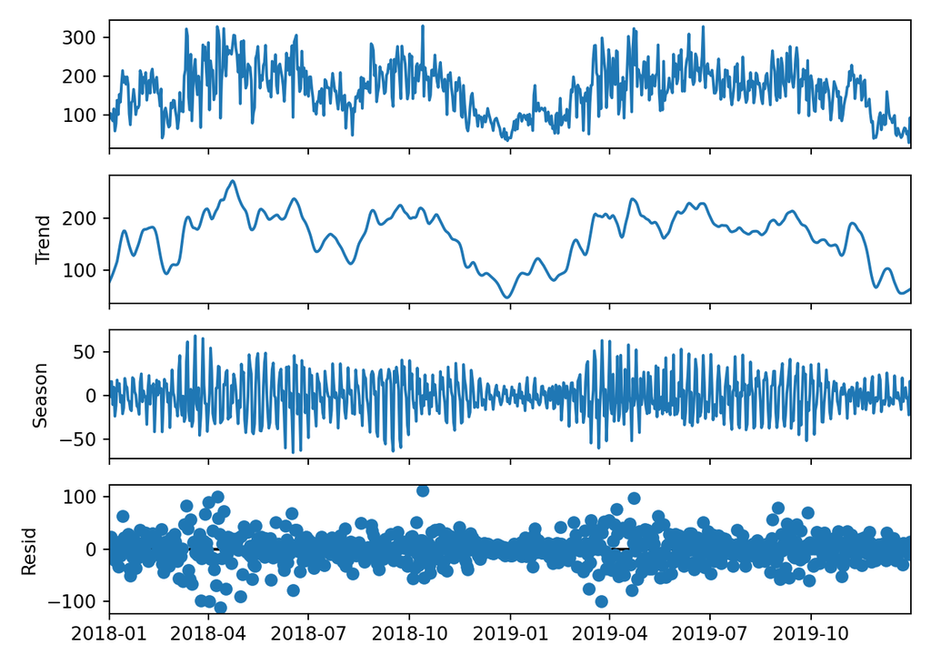

```python
# Load functions from packages
from statsmodels.tsa.seasonal import STL, seasonal_decompose

# Decompose the time series
# using STL()
stl = STL(myts, period=7)
myts_decomp1 = stl.fit()
(myts_decomp1.plot()).show()
```

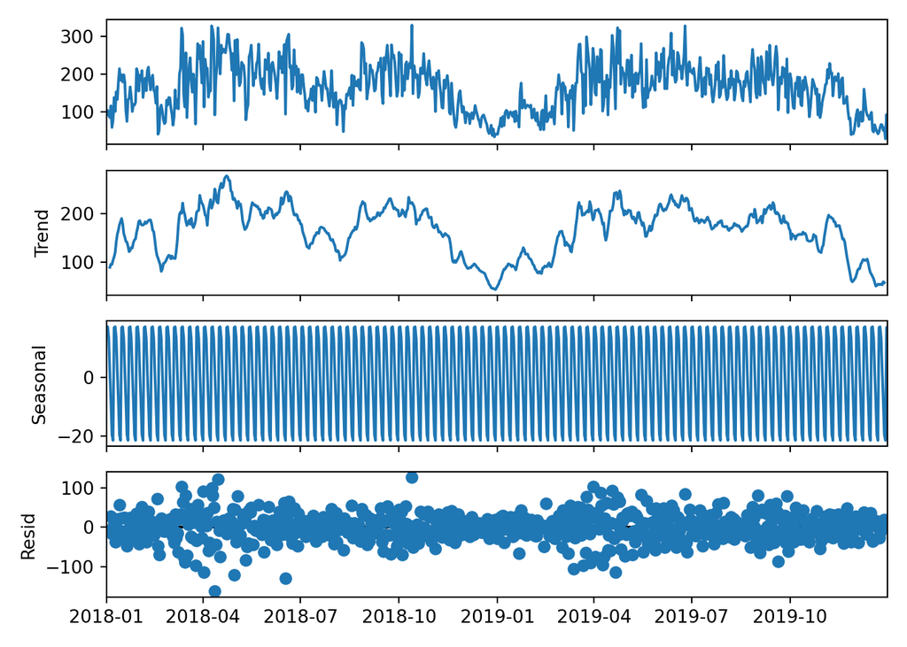

```python
# using seasonal_decompose() & additive components
myts_decomp2 = seasonal_decompose(myts, model='additive', period=7)
(myts_decomp2.plot()).show()
```

Notice that each method splits the original time series (data or observed) into the seasonal, trend, and remainder (or random) components.

## Time series regression

Fundamentally, time series regression is trying to do the same thing as is done for linear regression: explain variations in *dependent variables (DV) $Y$* using one or more *independent variables (IVs) $X$*. The difference is that, for regression of a single time series, our DV $Y_t$ and our IVs $X_t$ are all time-varying variables; i.e., they change over time. Again, we can use both *continuous* and *categorical* IVs in our models.

Remember the seasonal component of our time series decomposition? We can remove this component (assuming additivity) using linear regression! We just have to include a categorical variable (with each day of the week) in our regression model. Let’s try it using a simple linear regression model and our original dataset. (Note: We do not need to create a *time series* variable for this to work.)

```r
# Time series regression model, seasonality
mymod1 <- lm(CountBL ~ Weekday, data=dat)
summary(mymod1)
```

```
Call:
lm(formula = CountBL ~ Weekday, data = dat)

Residuals:
     Min       1Q   Median       3Q      Max
-140.119  -45.259    4.557   42.335  183.538

Coefficients:
            Estimate Std. Error t value Pr(>|t|)
(Intercept) 181.2586     5.9899  30.261  < 2e-16 ***
WeekdayTue   -0.1391     8.4710  -0.016  0.98691
WeekdayWed   -2.7617     8.4914  -0.325  0.74509
WeekdayThu  -14.0880     8.4914  -1.659  0.09753 .
WeekdayFri  -24.2778     8.4914  -2.859  0.00437 **
WeekdaySat  -35.7970     8.4914  -4.216 2.81e-05 ***
WeekdaySun  -37.8158     8.4914  -4.453 9.79e-06 ***
---
Signif. codes:  0 '***' 0.001 '**' 0.01 '*' 0.05 '.' 0.1 ' ' 1

Residual standard error: 61.38 on 723 degrees of freedom
Multiple R-squared:  0.05848,   Adjusted R-squared:  0.05067
F-statistic: 7.485 on 6 and 723 DF,  p-value: 8.519e-08
```

```python
# Load packages
import statsmodels.formula.api as smf

# Time series regression model, seasonality
mymod1 = smf.ols("CountBL ~ Weekday", data=dat).fit()
mymod1.summary()
```

OLS Regression Results

| Dep. Variable: | CountBL | R-squared: | 0.058 |
| --- | --- | --- | --- |
| Model: | OLS | Adj. R-squared: | 0.051 |
| Method: | Least Squares | F-statistic: | 7.485 |
| Date: | Sat, 04 Oct 2025 | Prob (F-statistic): | 8.52e-08 |
| Time: | 15:53:58 | Log-Likelihood: | -4037.8 |
| No. Observations: | 730 | AIC: | 8090. |
| Df Residuals: | 723 | BIC: | 8122. |
| Df Model: | 6 |  |  |
| Covariance Type: | nonrobust |  |  |

|  | coef | std err | t | P>\|t\| | [0.025 | 0.975] |
| --- | --- | --- | --- | --- | --- | --- |
| Intercept | 181.2586 | 5.990 | 30.261 | 0.000 | 169.499 | 193.018 |
| Weekday[T.Tue] | -0.1391 | 8.471 | -0.016 | 0.987 | -16.770 | 16.492 |
| Weekday[T.Wed] | -2.7617 | 8.491 | -0.325 | 0.745 | -19.432 | 13.909 |
| Weekday[T.Thu] | -14.0880 | 8.491 | -1.659 | 0.098 | -30.759 | 2.583 |
| Weekday[T.Fri] | -24.2778 | 8.491 | -2.859 | 0.004 | -40.948 | -7.607 |
| Weekday[T.Sat] | -35.7970 | 8.491 | -4.216 | 0.000 | -52.468 | -19.126 |
| Weekday[T.Sun] | -37.8158 | 8.491 | -4.453 | 0.000 | -54.487 | -21.145 |

| Omnibus: | 7.322 | Durbin-Watson: | 0.633 |
| --- | --- | --- | --- |
| Prob(Omnibus): | 0.026 | Jarque-Bera (JB): | 5.012 |
| Skew: | 0.025 | Prob(JB): | 0.0816 |
| Kurtosis: | 2.597 | Cond. No. | 7.85 |

Notes:  
[1] Standard Errors assume that the covariance matrix of the errors is correctly specified.

Notice and interpret the linear regression outputs. The reference category for our “weekday” variable is Mon, so we interpret the parameters for the rest of the categories in comparison to that day. An average Mon sees non-motorized traffic of 181 people; Fri tends to see 24 less people, while Sun tends to see 38 less people. The p-values tell you about the hypothesis test of equal traffic on each weekday versus Mon.

Now, let’s plot our predicted values and residuals:

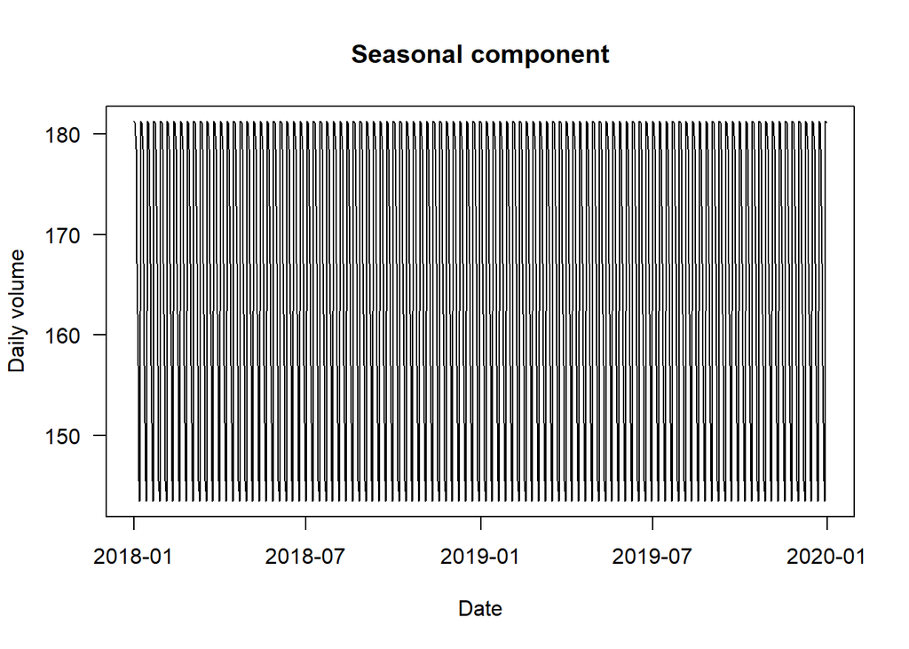

```r
# Plot results of time series regression
plot(dat$Date, mymod1$fitted.values, type="l", las=1,
  xlab="Date", ylab="Daily volume",
  main="Seasonal component") # plot predicted values (seasonal)
```

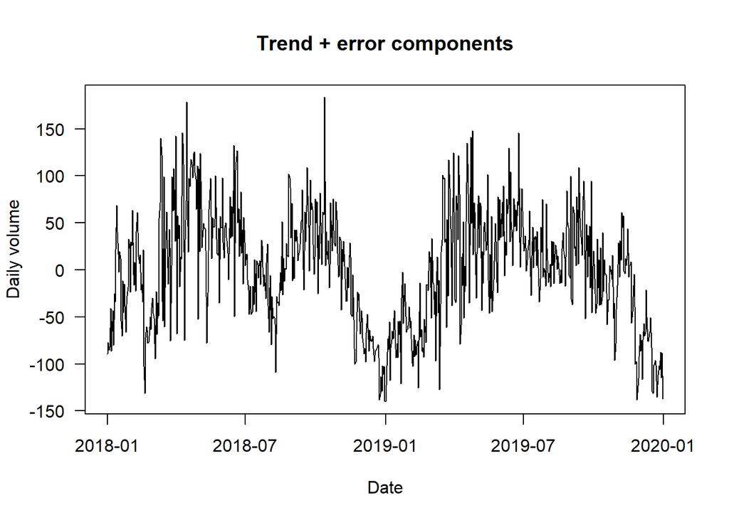

```r
plot(dat$Date, mymod1$residuals, type="l", las=1,
  xlab="Date", ylab="Daily volume",
  main="Trend + error components") # plot residuals (trend + error)
```

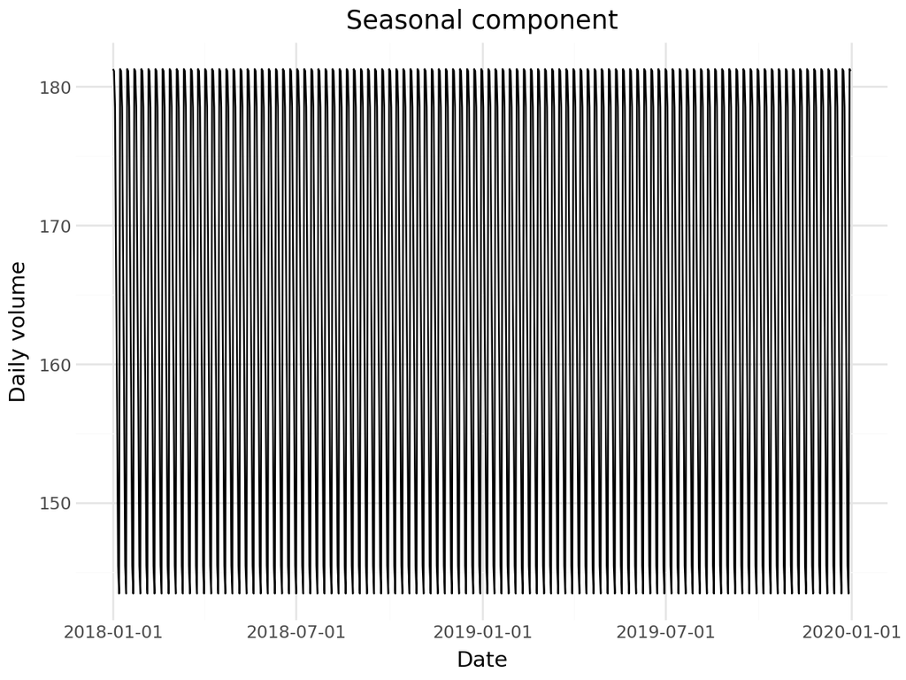

```python
# Get results of time series regression
dat["fitted"] = mymod1.fittedvalues
dat["resid"] = mymod1.resid

# Plot results of time series regression
(p9.ggplot(dat, p9.aes(x="Date", y="fitted")) +
  p9.geom_line() +
  p9.labs(x="Date", y="Daily volume",
    title="Seasonal component") +
  p9.theme_minimal()
  ).show() # plot predicted values (seasonal)
```

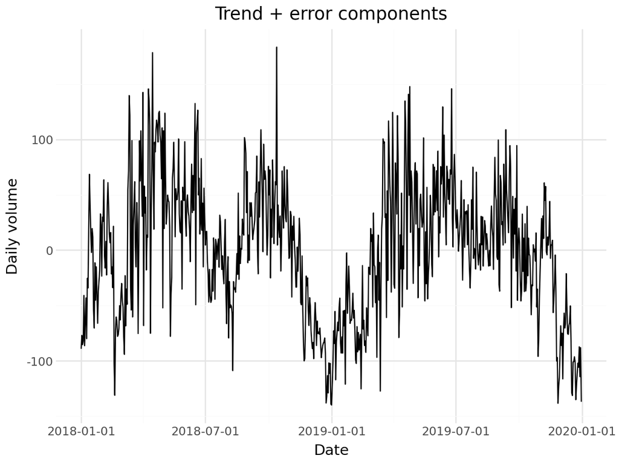

```python
(p9.ggplot(dat, p9.aes(x="Date", y="resid")) +
  p9.geom_line() +
  p9.labs(x="Date", y="Daily volume",
    title="Trend + error components") +
  p9.theme_minimal()
  ).show() # plot residuals (trend + error)
```

Notice that the plot of the predicted values $\hat Y_t$ looks just like the seasonal plots from the decomposition functions. That’s because we are only including IVs to represent the average variations within a week. Our plot of residuals looks like a combination of the trend and error plots we saw earlier; that’s because it is!

Now, let’s try to account for true seasonal (monthly) variation.

In R, we’ll use the `update()` function to change the formula of our model. (The `.` symbols indicate to use the same thing as before.)

```r
# Time series regression model, with weekdays + months
mymod2 <- update(mymod1, formula= . ~ . + Month)
summary(mymod2)
```

```
Call:
lm(formula = CountBL ~ Weekday + Month, data = dat)

Residuals:
     Min       1Q   Median       3Q      Max
-139.243  -28.740   -0.503   26.602  173.252

Coefficients:
             Estimate Std. Error t value Pr(>|t|)
(Intercept) 132.79597    7.07803  18.762  < 2e-16 ***
WeekdayTue   -0.08283    6.27056  -0.013 0.989465
WeekdayWed   -3.32537    6.28829  -0.529 0.597095
WeekdayThu  -14.91349    6.28976  -2.371 0.018002 *
WeekdayFri  -25.58921    6.29126  -4.067 5.28e-05 ***
WeekdaySat  -36.96730    6.28930  -5.878 6.39e-09 ***
WeekdaySun  -38.57429    6.28585  -6.137 1.40e-09 ***
MonthFeb      7.28653    8.37555   0.870 0.384606
MonthMar     60.77211    8.16407   7.444 2.83e-13 ***
MonthApr    102.57532    8.22847  12.466  < 2e-16 ***
MonthMay     80.28097    8.15963   9.839  < 2e-16 ***
MonthJun    101.78267    8.23107  12.366  < 2e-16 ***
MonthJul     53.32799    8.15964   6.536 1.21e-10 ***
MonthAug     51.52761    8.16216   6.313 4.81e-10 ***
MonthSep     83.68297    8.23042  10.168  < 2e-16 ***
MonthOct     59.91935    8.15837   7.345 5.66e-13 ***
MonthNov     28.18202    8.23042   3.424 0.000652 ***
MonthDec    -40.15373    8.16217  -4.919 1.08e-06 ***
---
Signif. codes:  0 '***' 0.001 '**' 0.01 '*' 0.05 '.' 0.1 ' ' 1

Residual standard error: 45.42 on 712 degrees of freedom
Multiple R-squared:  0.4922,    Adjusted R-squared:  0.4801
F-statistic: 40.59 on 17 and 712 DF,  p-value: < 2.2e-16
```

```python
# Time series regression model, with weekdays + months
mymod2 = smf.ols("CountBL ~ Weekday + Month", data=dat).fit()
mymod2.summary()
```

OLS Regression Results

| Dep. Variable: | CountBL | R-squared: | 0.492 |
| --- | --- | --- | --- |
| Model: | OLS | Adj. R-squared: | 0.480 |
| Method: | Least Squares | F-statistic: | 40.59 |
| Date: | Sat, 04 Oct 2025 | Prob (F-statistic): | 9.10e-93 |
| Time: | 15:54:00 | Log-Likelihood: | -3812.4 |
| No. Observations: | 730 | AIC: | 7661. |
| Df Residuals: | 712 | BIC: | 7744. |
| Df Model: | 17 |  |  |
| Covariance Type: | nonrobust |  |  |

|  | coef | std err | t | P>\|t\| | [0.025 | 0.975] |
| --- | --- | --- | --- | --- | --- | --- |
| Intercept | 132.7960 | 7.078 | 18.762 | 0.000 | 118.900 | 146.692 |
| Weekday[T.Tue] | -0.0828 | 6.271 | -0.013 | 0.989 | -12.394 | 12.228 |
| Weekday[T.Wed] | -3.3254 | 6.288 | -0.529 | 0.597 | -15.671 | 9.020 |
| Weekday[T.Thu] | -14.9135 | 6.290 | -2.371 | 0.018 | -27.262 | -2.565 |
| Weekday[T.Fri] | -25.5892 | 6.291 | -4.067 | 0.000 | -37.941 | -13.238 |
| Weekday[T.Sat] | -36.9673 | 6.289 | -5.878 | 0.000 | -49.315 | -24.620 |
| Weekday[T.Sun] | -38.5743 | 6.286 | -6.137 | 0.000 | -50.915 | -26.233 |
| Month[T.Feb] | 7.2865 | 8.376 | 0.870 | 0.385 | -9.157 | 23.730 |
| Month[T.Mar] | 60.7721 | 8.164 | 7.444 | 0.000 | 44.744 | 76.801 |
| Month[T.Apr] | 102.5753 | 8.228 | 12.466 | 0.000 | 86.420 | 118.730 |
| Month[T.May] | 80.2810 | 8.160 | 9.839 | 0.000 | 64.261 | 96.301 |
| Month[T.Jun] | 101.7827 | 8.231 | 12.366 | 0.000 | 85.623 | 117.943 |
| Month[T.Jul] | 53.3280 | 8.160 | 6.536 | 0.000 | 37.308 | 69.348 |
| Month[T.Aug] | 51.5276 | 8.162 | 6.313 | 0.000 | 35.503 | 67.552 |
| Month[T.Sep] | 83.6830 | 8.230 | 10.168 | 0.000 | 67.524 | 99.842 |
| Month[T.Oct] | 59.9194 | 8.158 | 7.345 | 0.000 | 43.902 | 75.937 |
| Month[T.Nov] | 28.1820 | 8.230 | 3.424 | 0.001 | 12.023 | 44.341 |
| Month[T.Dec] | -40.1537 | 8.162 | -4.919 | 0.000 | -56.179 | -24.129 |

| Omnibus: | 2.798 | Durbin-Watson: | 1.197 |
| --- | --- | --- | --- |
| Prob(Omnibus): | 0.247 | Jarque-Bera (JB): | 3.048 |
| Skew: | 0.008 | Prob(JB): | 0.218 |
| Kurtosis: | 3.316 | Cond. No. | 13.6 |

Notes:  
[1] Standard Errors assume that the covariance matrix of the errors is correctly specified.

It looks like this is monthly in addition to weekly variation. The $R^2$ value increased considerably. Again, let’s plot our predicted values and residuals:

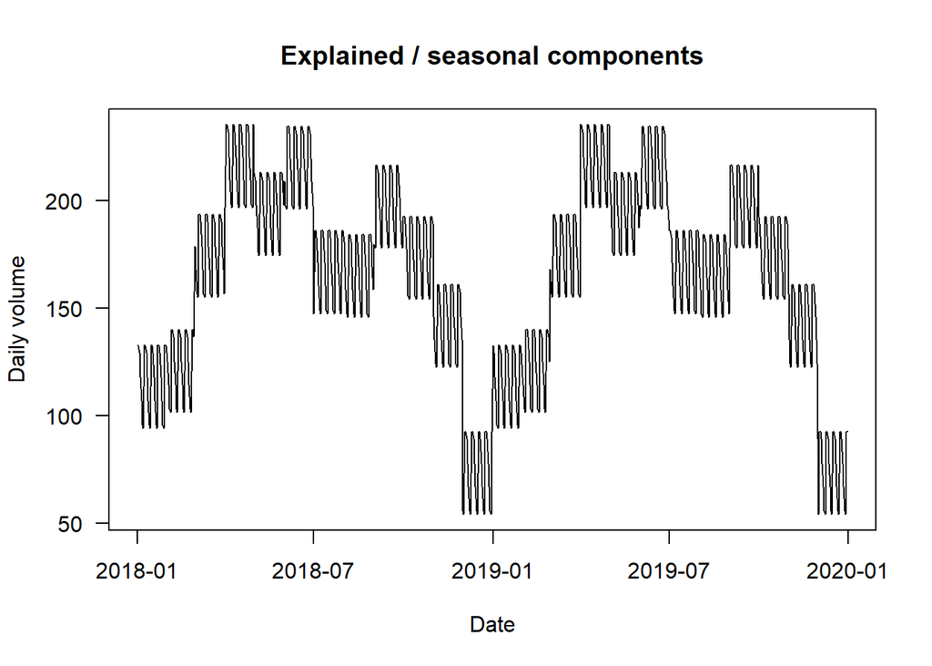

```r
# Plot results of time series regression
plot(dat$Date, mymod2$fitted.values, type="l", las=1,
  xlab="Date", ylab="Daily volume",
  main="Explained / seasonal components") # plot predicted values (seasonal)
```

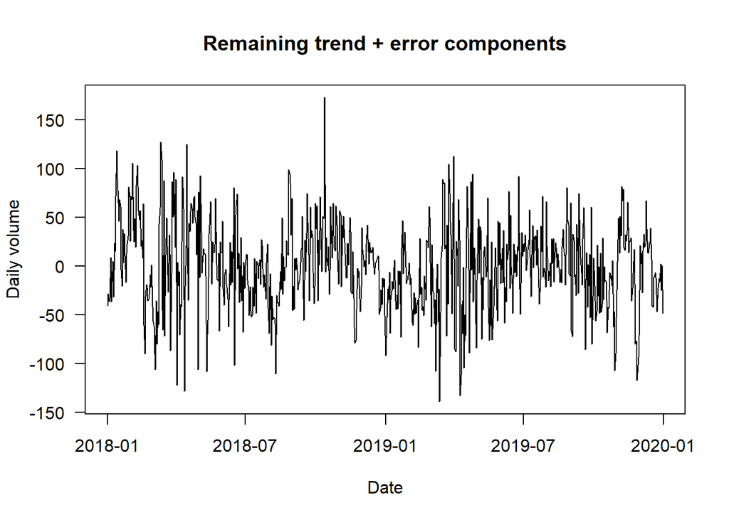

```r
plot(dat$Date, mymod2$residuals, type="l", las=1,
  xlab="Date", ylab="Daily volume",
  main="Remaining trend + error components") # plot residuals (trend + error)
```

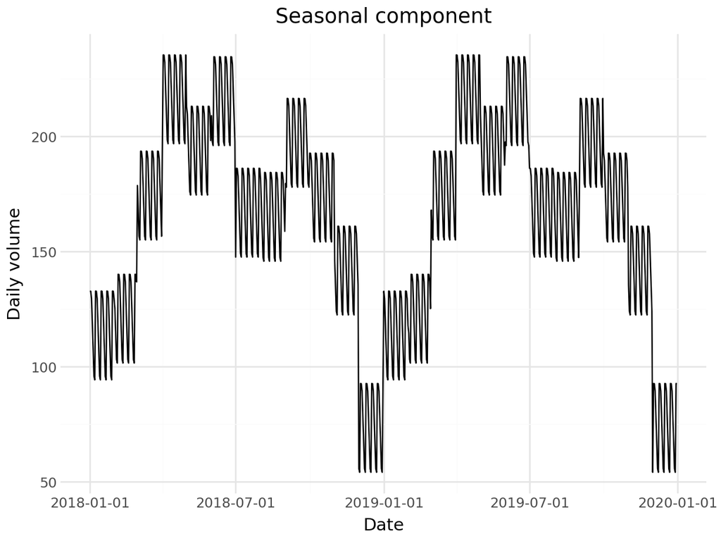

```python
# Get results of time series regression
dat["fitted"] = mymod2.fittedvalues
dat["resid"] = mymod2.resid

# Plot results of time series regression
(p9.ggplot(dat, p9.aes(x="Date", y="fitted")) +
  p9.geom_line() +
  p9.labs(x="Date", y="Daily volume",
    title="Seasonal component") +
  p9.theme_minimal()
  ).show() # plot predicted values (seasonal)
```

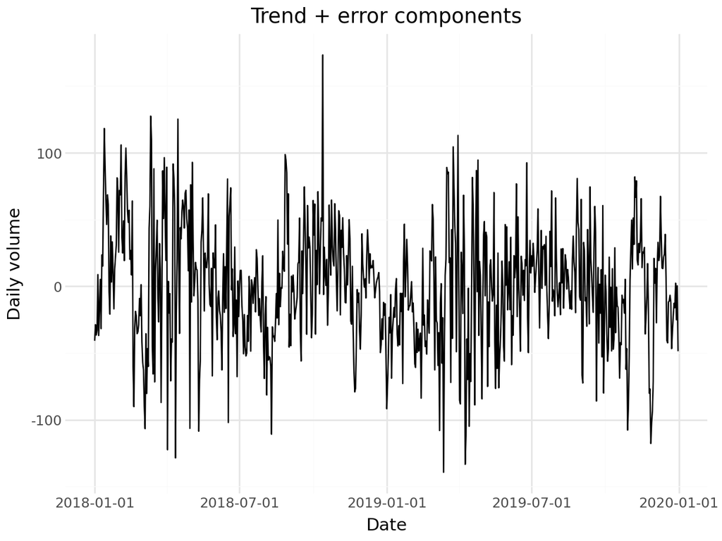

```python
(p9.ggplot(dat, p9.aes(x="Date", y="resid")) +
  p9.geom_line() +
  p9.labs(x="Date", y="Daily volume",
    title="Trend + error components") +
  p9.theme_minimal()
  ).show() # plot residuals (trend + error)
```

Now, let’s try to account for weather impacts on non-motorized traffic.

```r
# Time series regression model, with weekdays + months + weather
mymod3 <- update(mymod2, formula= . ~ . + Temp_Max + Temp_Min + Precipitation)
summary(mymod3)
```

```
Call:
lm(formula = CountBL ~ Weekday + Month + Temp_Max + Temp_Min +
    Precipitation, data = dat)

Residuals:
     Min       1Q   Median       3Q      Max
-149.744  -27.533   -0.665   27.432  170.379

Coefficients:
               Estimate Std. Error t value Pr(>|t|)
(Intercept)   109.04872    9.54595  11.424  < 2e-16 ***
WeekdayTue     -0.83128    6.02148  -0.138  0.89024
WeekdayWed     -2.37421    6.01691  -0.395  0.69326
WeekdayThu    -14.65774    6.01461  -2.437  0.01505 *
WeekdayFri    -24.16852    6.03095  -4.007 6.79e-05 ***
WeekdaySat    -36.74367    6.01436  -6.109 1.65e-09 ***
WeekdaySun    -38.39565    6.01903  -6.379 3.21e-10 ***
MonthFeb        5.74669    8.01865   0.717  0.47382
MonthMar       54.78495    8.05714   6.800 2.23e-11 ***
MonthApr       82.49399    9.07581   9.089  < 2e-16 ***
MonthMay       49.99114    9.96978   5.014 6.73e-07 ***
MonthJun       56.57406   11.50463   4.918 1.09e-06 ***
MonthJul       -4.34907   13.10391  -0.332  0.74007
MonthAug       -2.72508   12.68050  -0.215  0.82990
MonthSep       45.17208   11.24294   4.018 6.50e-05 ***
MonthOct       41.32470    8.74265   4.727 2.75e-06 ***
MonthNov       18.01689    8.10388   2.223  0.02651 *
MonthDec      -40.08246    7.82649  -5.121 3.91e-07 ***
Temp_Max        0.05571    0.32769   0.170  0.86506
Temp_Min        1.23479    0.39683   3.112  0.00194 **
Precipitation -67.94588   11.13970  -6.099 1.75e-09 ***
---
Signif. codes:  0 '***' 0.001 '**' 0.01 '*' 0.05 '.' 0.1 ' ' 1

Residual standard error: 43.43 on 709 degrees of freedom
Multiple R-squared:  0.5378,    Adjusted R-squared:  0.5248
F-statistic: 41.25 on 20 and 709 DF,  p-value: < 2.2e-16
```

```python
# Time series regression model, with weekdays + months + weather
mymod3 = smf.ols("CountBL ~ Weekday + Month + Temp_Max + Temp_Min + Precipitation", data=dat).fit()
mymod3.summary()
```

OLS Regression Results

| Dep. Variable: | CountBL | R-squared: | 0.538 |
| --- | --- | --- | --- |
| Model: | OLS | Adj. R-squared: | 0.525 |
| Method: | Least Squares | F-statistic: | 41.25 |
| Date: | Sat, 04 Oct 2025 | Prob (F-statistic): | 1.61e-104 |
| Time: | 15:54:02 | Log-Likelihood: | -3778.1 |
| No. Observations: | 730 | AIC: | 7598. |
| Df Residuals: | 709 | BIC: | 7695. |
| Df Model: | 20 |  |  |
| Covariance Type: | nonrobust |  |  |

|  | coef | std err | t | P>\|t\| | [0.025 | 0.975] |
| --- | --- | --- | --- | --- | --- | --- |
| Intercept | 109.0487 | 9.546 | 11.424 | 0.000 | 90.307 | 127.790 |
| Weekday[T.Tue] | -0.8313 | 6.021 | -0.138 | 0.890 | -12.653 | 10.991 |
| Weekday[T.Wed] | -2.3742 | 6.017 | -0.395 | 0.693 | -14.187 | 9.439 |
| Weekday[T.Thu] | -14.6577 | 6.015 | -2.437 | 0.015 | -26.466 | -2.849 |
| Weekday[T.Fri] | -24.1685 | 6.031 | -4.007 | 0.000 | -36.009 | -12.328 |
| Weekday[T.Sat] | -36.7437 | 6.014 | -6.109 | 0.000 | -48.552 | -24.936 |
| Weekday[T.Sun] | -38.3956 | 6.019 | -6.379 | 0.000 | -50.213 | -26.578 |
| Month[T.Feb] | 5.7467 | 8.019 | 0.717 | 0.474 | -9.996 | 21.490 |
| Month[T.Mar] | 54.7849 | 8.057 | 6.800 | 0.000 | 38.966 | 70.604 |
| Month[T.Apr] | 82.4940 | 9.076 | 9.089 | 0.000 | 64.675 | 100.313 |
| Month[T.May] | 49.9911 | 9.970 | 5.014 | 0.000 | 30.417 | 69.565 |
| Month[T.Jun] | 56.5741 | 11.505 | 4.918 | 0.000 | 33.987 | 79.161 |
| Month[T.Jul] | -4.3491 | 13.104 | -0.332 | 0.740 | -30.076 | 21.378 |
| Month[T.Aug] | -2.7251 | 12.680 | -0.215 | 0.830 | -27.621 | 22.171 |
| Month[T.Sep] | 45.1721 | 11.243 | 4.018 | 0.000 | 23.099 | 67.246 |
| Month[T.Oct] | 41.3247 | 8.743 | 4.727 | 0.000 | 24.160 | 58.489 |
| Month[T.Nov] | 18.0169 | 8.104 | 2.223 | 0.027 | 2.106 | 33.927 |
| Month[T.Dec] | -40.0825 | 7.826 | -5.121 | 0.000 | -55.448 | -24.717 |
| Temp_Max | 0.0557 | 0.328 | 0.170 | 0.865 | -0.588 | 0.699 |
| Temp_Min | 1.2348 | 0.397 | 3.112 | 0.002 | 0.456 | 2.014 |
| Precipitation | -67.9459 | 11.140 | -6.099 | 0.000 | -89.817 | -46.075 |

| Omnibus: | 6.708 | Durbin-Watson: | 1.386 |
| --- | --- | --- | --- |
| Prob(Omnibus): | 0.035 | Jarque-Bera (JB): | 9.291 |
| Skew: | -0.002 | Prob(JB): | 0.00961 |
| Kurtosis: | 3.553 | Cond. No. | 1.26e+03 |

Notes:  
[1] Standard Errors assume that the covariance matrix of the errors is correctly specified.  
[2] The condition number is large, 1.26e+03. This might indicate that there are  
strong multicollinearity or other numerical problems.

It looks like we see some impacts of weather: traffic seems to go up slightly on days with higher minimum temperatures and down on days with more precipitation. However, I’m guessing we have some non-linear relationships and multicollinarity in our model: max/min temperatures tend to trend together, and effects may not be present except in more extreme situations (high or low temps, lots of rain).

So, let’s consider some of these extreme situations. I’m guessing (hypothesizing) there might not be temperature effects until above 90F, below freezing (32F), and above 0in. (You can make your own guesses.) So, I’ll create dummy variables for these and re-estimate my model.

In R, we can wrap these conditional statements in the function `I()`:

```r
# Time series regression model, with weekdays + months + weather
mymod4 <- update(mymod2, formula= . ~ . + I(Temp_Max>90) + I(Temp_Min<32) + I(Precipitation>0))
summary(mymod4)
```

```
Call:
lm(formula = CountBL ~ Weekday + Month + I(Temp_Max > 90) + I(Temp_Min <
    32) + I(Precipitation > 0), data = dat)

Residuals:
     Min       1Q   Median       3Q      Max
-138.211  -26.397   -0.592   27.863  160.754

Coefficients:
                         Estimate Std. Error t value Pr(>|t|)
(Intercept)              170.0752     8.3574  20.350  < 2e-16 ***
WeekdayTue                 0.2255     5.9221   0.038  0.96963
WeekdayWed                -3.2847     5.9380  -0.553  0.58032
WeekdayThu               -15.8298     5.9374  -2.666  0.00785 **
WeekdayFri               -25.8900     5.9438  -4.356 1.52e-05 ***
WeekdaySat               -38.3067     5.9356  -6.454 2.02e-10 ***
WeekdaySun               -40.1998     5.9390  -6.769 2.72e-11 ***
MonthFeb                   4.0665     7.9460   0.512  0.60897
MonthMar                  57.5732     7.7659   7.414 3.51e-13 ***
MonthApr                  81.1353     8.8813   9.135  < 2e-16 ***
MonthMay                  55.1921     9.0934   6.069 2.09e-09 ***
MonthJun                  68.3418     9.1925   7.435 3.03e-13 ***
MonthJul                  31.0070    10.1456   3.056  0.00233 **
MonthAug                  23.9738     9.4345   2.541  0.01126 *
MonthSep                  52.6396     9.1944   5.725 1.53e-08 ***
MonthOct                  36.4772     8.4561   4.314 1.83e-05 ***
MonthNov                  20.0649     7.8507   2.556  0.01080 *
MonthDec                 -35.6267     7.7136  -4.619 4.59e-06 ***
I(Temp_Max > 90)TRUE     -20.7524     7.3492  -2.824  0.00488 **
I(Temp_Min < 32)TRUE     -32.4970     5.4227  -5.993 3.28e-09 ***
I(Precipitation > 0)TRUE -25.5888     3.7735  -6.781 2.51e-11 ***
---
Signif. codes:  0 '***' 0.001 '**' 0.01 '*' 0.05 '.' 0.1 ' ' 1

Residual standard error: 42.84 on 709 degrees of freedom
Multiple R-squared:  0.5503,    Adjusted R-squared:  0.5376
F-statistic: 43.37 on 20 and 709 DF,  p-value: < 2.2e-16
```

In Python, we need to create new variables before we can use them in the model:

```python
# Create new variables
dat["TMAX90"] = (dat["Temp_Max"] > 90).astype(int)
dat["TMIN32"] = (dat["Temp_Min"] < 32).astype(int)
dat["PRCPANY"] = (dat["Precipitation"] > 0).astype(int)

# Time series regression model, with weekdays + months + weather
mymod4 = smf.ols("CountBL ~ Weekday + Month + TMAX90 + TMIN32 + PRCPANY", data=dat).fit()
mymod4.summary()
```

OLS Regression Results

| Dep. Variable: | CountBL | R-squared: | 0.550 |
| --- | --- | --- | --- |
| Model: | OLS | Adj. R-squared: | 0.538 |
| Method: | Least Squares | F-statistic: | 43.37 |
| Date: | Sat, 04 Oct 2025 | Prob (F-statistic): | 1.24e-108 |
| Time: | 15:54:02 | Log-Likelihood: | -3768.1 |
| No. Observations: | 730 | AIC: | 7578. |
| Df Residuals: | 709 | BIC: | 7675. |
| Df Model: | 20 |  |  |
| Covariance Type: | nonrobust |  |  |

|  | coef | std err | t | P>\|t\| | [0.025 | 0.975] |
| --- | --- | --- | --- | --- | --- | --- |
| Intercept | 170.0752 | 8.357 | 20.350 | 0.000 | 153.667 | 186.483 |
| Weekday[T.Tue] | 0.2255 | 5.922 | 0.038 | 0.970 | -11.401 | 11.852 |
| Weekday[T.Wed] | -3.2847 | 5.938 | -0.553 | 0.580 | -14.943 | 8.373 |
| Weekday[T.Thu] | -15.8298 | 5.937 | -2.666 | 0.008 | -27.487 | -4.173 |
| Weekday[T.Fri] | -25.8900 | 5.944 | -4.356 | 0.000 | -37.560 | -14.220 |
| Weekday[T.Sat] | -38.3067 | 5.936 | -6.454 | 0.000 | -49.960 | -26.653 |
| Weekday[T.Sun] | -40.1998 | 5.939 | -6.769 | 0.000 | -51.860 | -28.540 |
| Month[T.Feb] | 4.0665 | 7.946 | 0.512 | 0.609 | -11.534 | 19.667 |
| Month[T.Mar] | 57.5732 | 7.766 | 7.414 | 0.000 | 42.326 | 72.820 |
| Month[T.Apr] | 81.1353 | 8.881 | 9.135 | 0.000 | 63.698 | 98.572 |
| Month[T.May] | 55.1921 | 9.093 | 6.069 | 0.000 | 37.339 | 73.045 |
| Month[T.Jun] | 68.3418 | 9.193 | 7.435 | 0.000 | 50.294 | 86.390 |
| Month[T.Jul] | 31.0070 | 10.146 | 3.056 | 0.002 | 11.088 | 50.926 |
| Month[T.Aug] | 23.9738 | 9.434 | 2.541 | 0.011 | 5.451 | 42.497 |
| Month[T.Sep] | 52.6396 | 9.194 | 5.725 | 0.000 | 34.588 | 70.691 |
| Month[T.Oct] | 36.4772 | 8.456 | 4.314 | 0.000 | 19.875 | 53.079 |
| Month[T.Nov] | 20.0649 | 7.851 | 2.556 | 0.011 | 4.652 | 35.478 |
| Month[T.Dec] | -35.6267 | 7.714 | -4.619 | 0.000 | -50.771 | -20.482 |
| TMAX90 | -20.7524 | 7.349 | -2.824 | 0.005 | -35.181 | -6.324 |
| TMIN32 | -32.4970 | 5.423 | -5.993 | 0.000 | -43.144 | -21.851 |
| PRCPANY | -25.5888 | 3.774 | -6.781 | 0.000 | -32.997 | -18.180 |

| Omnibus: | 6.019 | Durbin-Watson: | 1.470 |
| --- | --- | --- | --- |
| Prob(Omnibus): | 0.049 | Jarque-Bera (JB): | 6.524 |
| Skew: | 0.143 | Prob(JB): | 0.0383 |
| Kurtosis: | 3.364 | Cond. No. | 17.7 |

Notes:  
[1] Standard Errors assume that the covariance matrix of the errors is correctly specified.

Comparing our model results to the one above, we seem to have improved things slightly ($R^2$), and all our weather variables are now significant. Result will depend upon what you assume for your weather extremes and your specific time series.

## Time series regression assumptions

Regression with time series involves additional issues and concepts, due to the nature of time series data. There are more complicated considerations with time series analysis, which is more complicated than regular linear regression.

### Autocorrelation and stationarity

Two concepts are particularly important to understand when analyzing time series data: *stationarity* and *autocorrelation*.

- **Stationarity**: A time series $X_t$ must be at least *weakly stationary*; the mean and covariance of the time series must be constant over time.
  - First, this means that the mean of the times series $\sum_{t=t_1}^{t_1+L} \frac {X_t} {L}$ must be time invariant; that is, it cannot depend on the time interval $L$ or the start time $t_1$. It must be horizontal or without a trend.
  - Second, this means that the covariance between two observations of the time series $Cov(X_{t_1}, X_{t_1 + L})$ must also be time invariant. This covariance is called autocovariance $\gamma_K$. The variance of the time series is similar: $Var(X_t) = \gamma_0$.
  - This time difference $L$ is commonly called the “lag”. It refers to how many observations in the future (or the past) is being influenced by the observation.
- **Autocorrelation**: The *autocorrelation* or serial correlation of a time series $X_t$ refers to the association between observations over a time interval or lag $L$.
  - The *autocorrelation coefficient* for a given lag $L$ is calculated as $\rho_L = \frac {Cov(X_t, X_{t-L})} {\sqrt {Var(X_t) Var X_{t-L}}} = \frac {Cov(X_t, X_{t-L})} {Var(X_t)} = \frac {\gamma_L} {\gamma_0}$.
  - If a time series is weakly stationary, $\rho_0 = 1$, $\rho_L = \rho_{-L}$, and $-1<\rho_L<1$. That is, the autocorrelation coefficient for any forward lag is equal to the same reverse lag, and all autocorrelation coefficients are between -1 and 1.
  - If a time series is non-stationary, then $|\rho_L| > 1$. The relationship between observations explodes.
  - A related term is the *partial autocorrelation coefficient* $\phi_{LL}$. It is the correlation between observations after removing any intervening effects.

#### Detecting non-stationarity and autocorrelation

We can visually check for stationarity and autocorrelation using plots of the autocorrelation (and partial autocorrelation) coefficients. First, let’s look at our original time series data:

In R, use the `acf()` and `pacf()` functions.

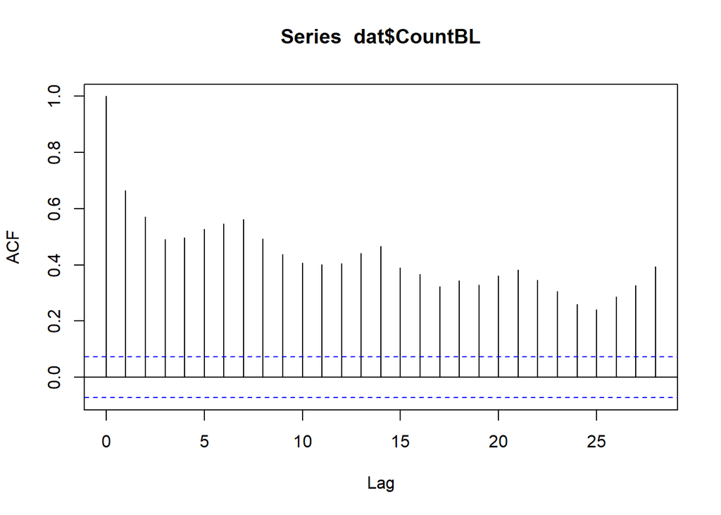

```r
# Plot autocorrelation coefficients
acf(dat$CountBL)
```

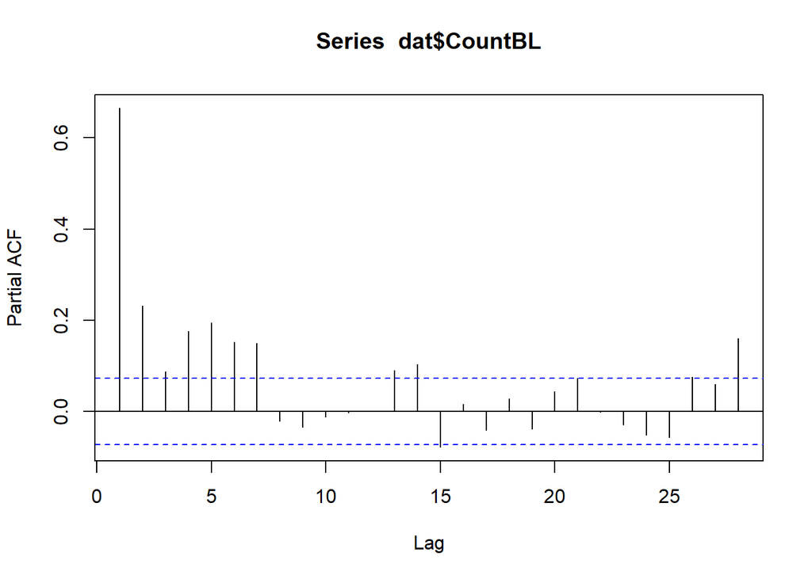

```r
# Plot partial autocorrelation coefficients
pacf(dat$CountBL)
```

In Python, use the `plot_acf()` and `plot_pacf()` functions from `statsmodels`.

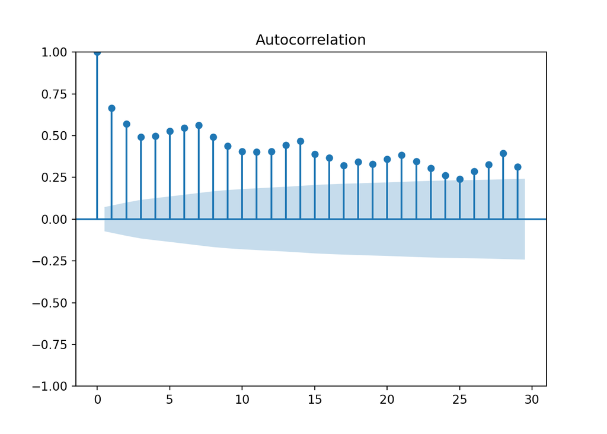

```python
# Load functions from packages
from statsmodels.graphics.tsaplots import plot_acf, plot_pacf

# Plot autocorrelation coefficients
plot_acf(dat["CountBL"])
```

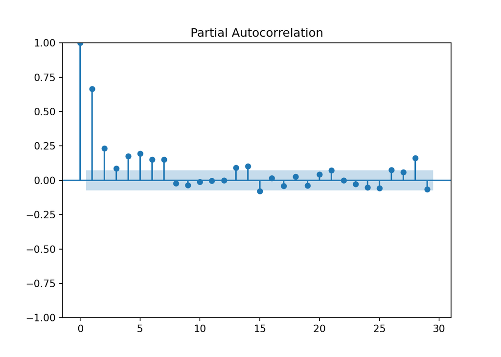

```python
# Plot partial autocorrelation coefficients
plot_pacf(dat["CountBL"])
```

Now, let’s look at the residuals from our time series regression, having removed the seasonal component and some of the trend:

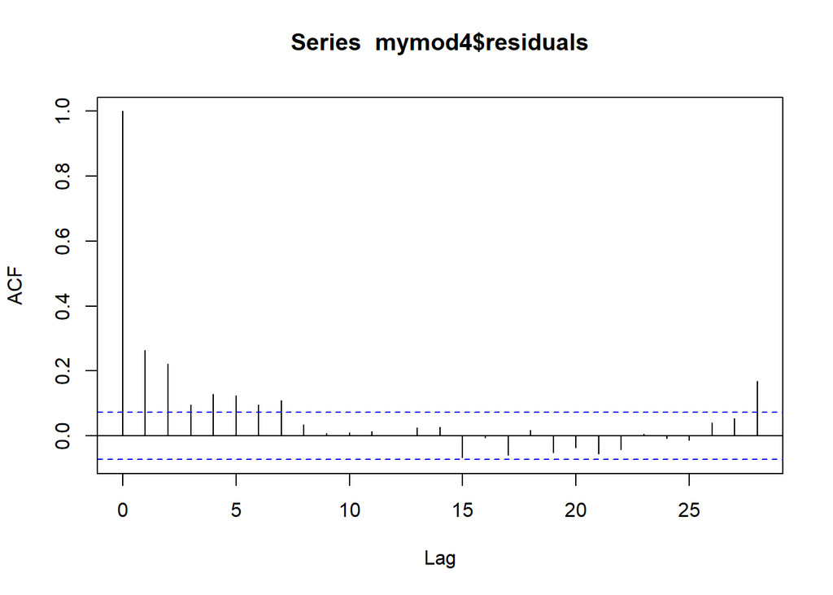

```r
# Plot autocorrelation coefficients
acf(mymod4$residuals)
```

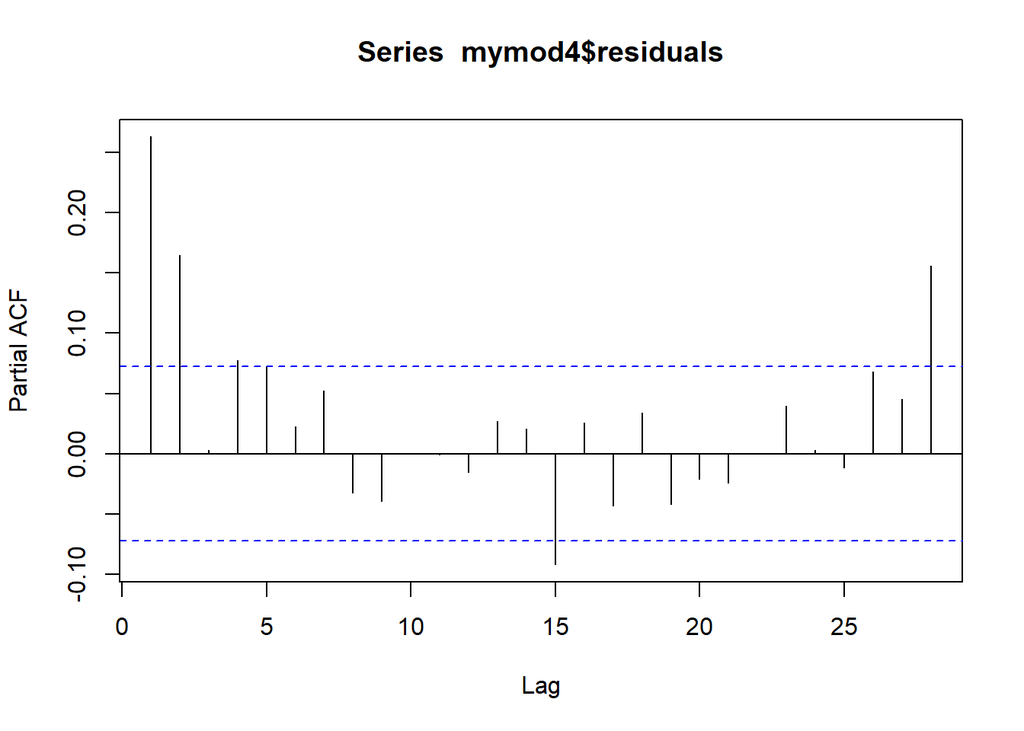

```r
# Plot partial autocorrelation coefficients
pacf(mymod4$residuals)
```

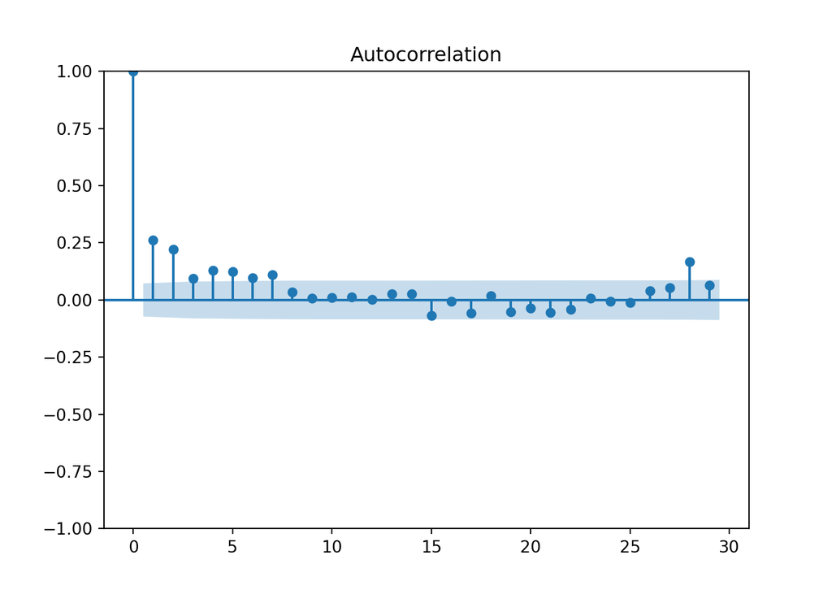

```python
# Plot autocorrelation coefficients
plot_acf(mymod4.resid)
```

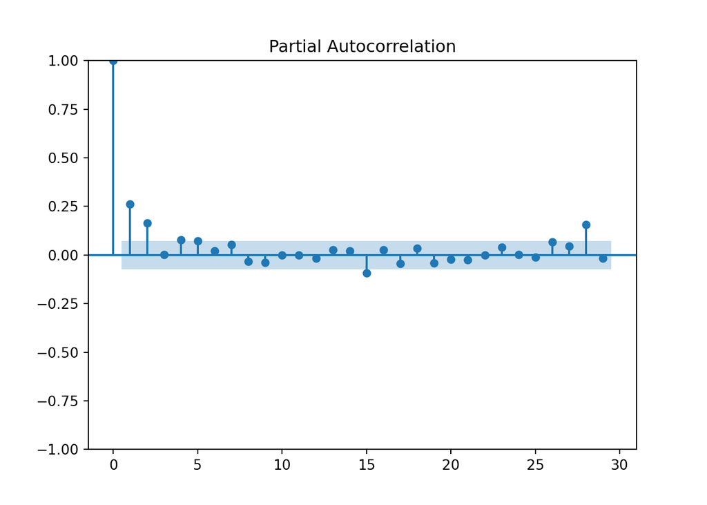

```python
# Plot partial autocorrelation coefficients
plot_pacf(mymod4.resid)
```

This plots look somewhat better, although there are still some moderate autocorrelation coefficients at several lags, especially for $\gamma_0 = 1$, which we would expect from the weak stationarity assumption.

We can also calculate statistics to investigate stationarity and autocorrelation. The [Ljung-Box test](https://en.wikipedia.org/wiki/Ljung%E2%80%93Box_test) and the [Breusch-Godfrey test](https://en.wikipedia.org/wiki/Breusch%E2%80%93Godfrey_test) both examine the null hypothesis of no autocorrelation $H_0: \rho_1 = ... = \rho_m = 0$ for a given number of lags. Let’s examine our original time series first, and then the residuals from our regression.

In R, you can use the `Box.text()` function on the residuals for the Ljung-Box test, and/or the `bgtest()` function on the model for the Breusch-Godfrey test.

```r
# install.packages("lmtest")
library("lmtest")

# Original time series data
Box.test(dat$CountBL, lag=14, type="Ljung-Box") # Ljung-Box test
```

```
    Box-Ljung test

data:  dat$CountBL
X-squared = 2575.5, df = 14, p-value < 2.2e-16
```

```r
# Time series regression residuals
Box.test(mymod4$residuals, lag=7, type="Ljung-Box") # Ljung-Box test
```

```
    Box-Ljung test

data:  mymod4$residuals
X-squared = 133.08, df = 7, p-value < 2.2e-16
```

```r
bgtest(mymod4, order=7) # Breusch-Godfrey test
```

```
    Breusch-Godfrey test for serial correlation of order up to 7

data:  mymod4
LM test = 89.683, df = 7, p-value < 2.2e-16
```

In Python, you can use the `acorr_ljungbox()` function on the residuals for the Ljung-Box test, and/or the `acorr_breusch_godfrey()` function on the model for the Breusch-Godfrey test, both from `statsmodels`.

```python
# Import functions from packages
from statsmodels.stats.diagnostic import acorr_ljungbox
from statsmodels.stats.diagnostic import acorr_breusch_godfrey

# Original time series data
LB1 = acorr_ljungbox(dat["CountBL"], lags=[14], return_df=True)
print("Ljung-Box Test Results:")
```

```
Ljung-Box Test Results:
```

```python
print(LB1)
```

```
        lb_stat  lb_pvalue
14  2575.525193        0.0
```

```python
# Time series regression residuals
LB2 = acorr_ljungbox(mymod4.resid, lags=[7], return_df=True)
print("Ljung-Box Test Results:")
```

```
Ljung-Box Test Results:
```

```python
print(LB2)
```

```
      lb_stat     lb_pvalue
7  133.079252  1.427932e-25
```

```python
BG2 = acorr_breusch_godfrey(mymod4, nlags=7)
print("Breusch-Godfrey Test Results:")
```

```
Breusch-Godfrey Test Results:
```

```python
print(f"LM Statistic: {BG2[0]}")
```

```
LM Statistic: 89.68331292827457
```

```python
print(f"LM p-value: {BG2[1]}")
```

```
LM p-value: 1.4370791494783515e-16
```

```python
print(f"F Statistic: {BG2[2]}")
```

```
F Statistic: 14.046104495030674
```

```python
print(f"F p-value: {BG2[3]}")
```

```
F p-value: 4.0826608377319696e-17
```

```python
# Remove
del LB1, LB2, BG2
```

The original time series exhibits significant autocorrelation up to 7 and even 14 lags. This is not surprising based on our observation of the ACF plot. However, the results also indicate that we do have autocorrelation. An inspection of the ACF plot suggests that first-order autocorrelation may remain in our model.

#### Dealing with non-stationarity

If our time series was non-stationary (after doing other filtering and de-trending, as we did earlier), the most common approach to creating a stationary time series is through **differencing**. For first-order differencing, this process basically creates a new time series data that is the difference between an observation and its previous value: $Z_t = X_t - X_{t-1}$. Then, you can check for stationarity again using the same methods as shown above.

#### Dealing with autocorrelation

If you find autocorrelation in your time series, there are a number of approaches to accounting for the presence of serial correlation.

- One method is to account for first-order serial correlation by transforming the time series variables in our model. This transformation basically subtracts a portion of the previous observation, depending on the strength of the autocorrelation coefficient $\rho_1$: $Y_t^\prime = Y_t - \rho_1 Y_{t-1}$, $X_t^\prime = Y_t - \rho_1 Y_{t-1}$, and $u_t = \epsilon_t - \rho_1 \epsilon_{t-1}$. The regression now proceeds with the transformed variables: $Y_t^\prime = \beta_0 + \beta_1 X_t^\prime + ... + u_t$.
  - This is the common first-order autoregressive model known as AR(1).
  - There are several ways to estimate the appropriate autocorrelation coefficient $\rho_1$: the [Cochrane-Orcutt method](https://en.wikipedia.org/wiki/Cochrane%E2%80%93Orcutt_estimation), the [Prais-Winsten method](https://en.wikipedia.org/wiki/Prais%E2%80%93Winsten_estimation), the [Hildreth-Lu search procedure](https://en.wikipedia.org/wiki/Hildreth%E2%80%93Lu_estimation), and many others.

For example, in R we can use the Cochrane-Orcutt function `cochorc()` from the `desk` package.

```r
# Load packages
library("desk")

# AR(1) model with Cochrane-Orcutt method
mymod5 <- cochorc(mymod4)
summary(mymod4) # original model
```

```
Call:
lm(formula = CountBL ~ Weekday + Month + I(Temp_Max > 90) + I(Temp_Min <
    32) + I(Precipitation > 0), data = dat)

Residuals:
     Min       1Q   Median       3Q      Max
-138.211  -26.397   -0.592   27.863  160.754

Coefficients:
                         Estimate Std. Error t value Pr(>|t|)
(Intercept)              170.0752     8.3574  20.350  < 2e-16 ***
WeekdayTue                 0.2255     5.9221   0.038  0.96963
WeekdayWed                -3.2847     5.9380  -0.553  0.58032
WeekdayThu               -15.8298     5.9374  -2.666  0.00785 **
WeekdayFri               -25.8900     5.9438  -4.356 1.52e-05 ***
WeekdaySat               -38.3067     5.9356  -6.454 2.02e-10 ***
WeekdaySun               -40.1998     5.9390  -6.769 2.72e-11 ***
MonthFeb                   4.0665     7.9460   0.512  0.60897
MonthMar                  57.5732     7.7659   7.414 3.51e-13 ***
MonthApr                  81.1353     8.8813   9.135  < 2e-16 ***
MonthMay                  55.1921     9.0934   6.069 2.09e-09 ***
MonthJun                  68.3418     9.1925   7.435 3.03e-13 ***
MonthJul                  31.0070    10.1456   3.056  0.00233 **
MonthAug                  23.9738     9.4345   2.541  0.01126 *
MonthSep                  52.6396     9.1944   5.725 1.53e-08 ***
MonthOct                  36.4772     8.4561   4.314 1.83e-05 ***
MonthNov                  20.0649     7.8507   2.556  0.01080 *
MonthDec                 -35.6267     7.7136  -4.619 4.59e-06 ***
I(Temp_Max > 90)TRUE     -20.7524     7.3492  -2.824  0.00488 **
I(Temp_Min < 32)TRUE     -32.4970     5.4227  -5.993 3.28e-09 ***
I(Precipitation > 0)TRUE -25.5888     3.7735  -6.781 2.51e-11 ***
---
Signif. codes:  0 '***' 0.001 '**' 0.01 '*' 0.05 '.' 0.1 ' ' 1

Residual standard error: 42.84 on 709 degrees of freedom
Multiple R-squared:  0.5503,    Adjusted R-squared:  0.5376
F-statistic: 43.37 on 20 and 709 DF,  p-value: < 2.2e-16
```

```r
mymod5$results # AR(1) model
```

```
                                 coef  std.err.      t.value      p.value
(Intercept)              155.06920029  9.943493 15.595042930 2.318270e-47
WeekdayTue                -0.03004547  4.909612 -0.006119723 9.951189e-01
WeekdayWed                -3.60032670  5.669348 -0.635051333 5.255998e-01
WeekdayThu               -15.78981553  5.874852 -2.687695712 7.363471e-03
WeekdayFri               -26.06891172  5.882866 -4.431328598 1.084758e-05
WeekdaySat               -37.96119620  5.669416 -6.695785891 4.365805e-11
WeekdaySun               -39.50209625  4.927566 -8.016553769 4.485455e-15
MonthFeb                   7.99250834 10.931569  0.731140108 4.649351e-01
MonthMar                  59.76497238 10.807509  5.529948651 4.506672e-08
MonthApr                  86.19412286 11.792012  7.309535049 7.248601e-13
MonthMay                  68.46008707 11.885763  5.759839307 1.254744e-08
MonthJun                  81.24690965 12.030264  6.753543212 3.007053e-11
MonthJul                  37.83577167 12.889065  2.935493985 3.437904e-03
MonthAug                  32.83200130 12.192924  2.692709408 7.254785e-03
MonthSep                  63.25638375 12.028943  5.258681891 1.923010e-07
MonthOct                  46.50760228 11.368535  4.090905450 4.790136e-05
MonthNov                  24.15240429 10.913334  2.213109654 2.720781e-02
MonthDec                 -34.31978257 10.715808 -3.202724693 1.422201e-03
I(Temp_Max > 90)TRUE      -6.70251028  8.134001 -0.824011439 4.102102e-01
I(Temp_Min < 32)TRUE     -21.22173873  5.774849 -3.674856251 2.559337e-04
I(Precipitation > 0)TRUE -14.50029212  3.679257 -3.941092405 8.914578e-05
```

```r
mymod5$rho.opt
```

```
[1] 0.3309643
```

In Python, there is no built-in functoin to use the Cochrane-Orcutt AR(1) method. Therefore, we must do all of the calculation steps ourselves:

```python
# Import functions from packages
from statsmodels.regression.linear_model import yule_walker
import statsmodels.api as sm

# Process data for more advanced modeling
tdat = dat
# - convert categoricals to dummy variables
tdat = pd.get_dummies(tdat, columns=["Month", "Weekday"])
tdat["const"] = 1
y = tdat["CountBL"]
X = tdat[["const", "Month_Feb", "Month_Mar", "Month_Apr", "Month_May", "Month_Jun",
  "Month_Jul", "Month_Aug", "Month_Sep", "Month_Oct", "Month_Nov", "Month_Dec",
  "Weekday_Tue", "Weekday_Wed", "Weekday_Thu", "Weekday_Fri", "Weekday_Sat", "Weekday_Sun",
  "TMAX90", "TMIN32", "PRCPANY"]]

# Cochrane-Orcutt method (AR(1) only)
# - estimate rho using Yule-Walker
rho, _ = yule_walker(mymod4.resid, order=1)
# - transform variables
y_trans = y[1:] - rho * y[:-1].values
X_trans = X[1:] - rho * X[:-1].values
y_trans = pd.to_numeric(y_trans, errors='coerce')
X_trans = X_trans.apply(pd.to_numeric, errors='coerce')
X_trans = X_trans.dropna()
y_trans = y_trans.loc[X_trans.index]
# - fit transformed model
mymod5 = sm.OLS(y_trans, X_trans).fit()

# Compare models
mymod4.summary() # original model
```

```
<class 'statsmodels.iolib.summary.Summary'>
"""
                            OLS Regression Results
==============================================================================
Dep. Variable:                CountBL   R-squared:                       0.550
Model:                            OLS   Adj. R-squared:                  0.538
Method:                 Least Squares   F-statistic:                     43.37
Date:                Sat, 04 Oct 2025   Prob (F-statistic):          1.24e-108
Time:                        15:54:06   Log-Likelihood:                -3768.1
No. Observations:                 730   AIC:                             7578.
Df Residuals:                     709   BIC:                             7675.
Df Model:                          20
Covariance Type:            nonrobust
==================================================================================
                     coef    std err          t      P>|t|      [0.025      0.975]
----------------------------------------------------------------------------------
Intercept        170.0752      8.357     20.350      0.000     153.667     186.483
Weekday[T.Tue]     0.2255      5.922      0.038      0.970     -11.401      11.852
Weekday[T.Wed]    -3.2847      5.938     -0.553      0.580     -14.943       8.373
Weekday[T.Thu]   -15.8298      5.937     -2.666      0.008     -27.487      -4.173
Weekday[T.Fri]   -25.8900      5.944     -4.356      0.000     -37.560     -14.220
Weekday[T.Sat]   -38.3067      5.936     -6.454      0.000     -49.960     -26.653
Weekday[T.Sun]   -40.1998      5.939     -6.769      0.000     -51.860     -28.540
Month[T.Feb]       4.0665      7.946      0.512      0.609     -11.534      19.667
Month[T.Mar]      57.5732      7.766      7.414      0.000      42.326      72.820
Month[T.Apr]      81.1353      8.881      9.135      0.000      63.698      98.572
Month[T.May]      55.1921      9.093      6.069      0.000      37.339      73.045
Month[T.Jun]      68.3418      9.193      7.435      0.000      50.294      86.390
Month[T.Jul]      31.0070     10.146      3.056      0.002      11.088      50.926
Month[T.Aug]      23.9738      9.434      2.541      0.011       5.451      42.497
Month[T.Sep]      52.6396      9.194      5.725      0.000      34.588      70.691
Month[T.Oct]      36.4772      8.456      4.314      0.000      19.875      53.079
Month[T.Nov]      20.0649      7.851      2.556      0.011       4.652      35.478
Month[T.Dec]     -35.6267      7.714     -4.619      0.000     -50.771     -20.482
TMAX90           -20.7524      7.349     -2.824      0.005     -35.181      -6.324
TMIN32           -32.4970      5.423     -5.993      0.000     -43.144     -21.851
PRCPANY          -25.5888      3.774     -6.781      0.000     -32.997     -18.180
==============================================================================
Omnibus:                        6.019   Durbin-Watson:                   1.470
Prob(Omnibus):                  0.049   Jarque-Bera (JB):                6.524
Skew:                           0.143   Prob(JB):                       0.0383
Kurtosis:                       3.364   Cond. No.                         17.7
==============================================================================

Notes:
[1] Standard Errors assume that the covariance matrix of the errors is correctly specified.
"""
```

```python
mymod5.summary() # Cochrane-Orcutt
```

```
<class 'statsmodels.iolib.summary.Summary'>
"""
                            OLS Regression Results
==============================================================================
Dep. Variable:                CountBL   R-squared:                       0.426
Model:                            OLS   Adj. R-squared:                  0.410
Method:                 Least Squares   F-statistic:                     26.24
Date:                Sat, 04 Oct 2025   Prob (F-statistic):           6.89e-72
Time:                        15:54:06   Log-Likelihood:                -3731.2
No. Observations:                 729   AIC:                             7504.
Df Residuals:                     708   BIC:                             7601.
Df Model:                          20
Covariance Type:            nonrobust
===============================================================================
                  coef    std err          t      P>|t|      [0.025      0.975]
-------------------------------------------------------------------------------
const         159.8965      9.555     16.734      0.000     141.136     178.657
Month_Feb       5.6486     10.134      0.557      0.577     -14.248      25.545
Month_Mar      58.0420      9.982      5.815      0.000      38.445      77.639
Month_Apr      84.1193     10.997      7.650      0.000      62.530     105.709
Month_May      63.9045     11.122      5.746      0.000      42.069      85.740
Month_Jun      77.2474     11.256      6.863      0.000      55.149      99.346
Month_Jul      35.0519     12.153      2.884      0.004      11.192      58.912
Month_Aug      29.7218     11.445      2.597      0.010       7.252      52.192
Month_Sep      59.9113     11.256      5.323      0.000      37.812      82.011
Month_Oct      43.0046     10.576      4.066      0.000      22.240      63.769
Month_Nov      22.0281     10.082      2.185      0.029       2.234      41.823
Month_Dec     -36.1691      9.909     -3.650      0.000     -55.623     -16.715
Weekday_Tue    -0.2766      5.059     -0.055      0.956     -10.210       9.656
Weekday_Wed    -3.9165      5.700     -0.687      0.492     -15.108       7.275
Weekday_Thu   -16.1865      5.844     -2.770      0.006     -27.660      -4.713
Weekday_Fri   -26.4241      5.850     -4.517      0.000     -37.910     -14.938
Weekday_Sat   -38.4023      5.698     -6.740      0.000     -49.588     -27.216
Weekday_Sun   -39.9506      5.076     -7.870      0.000     -49.916     -29.985
TMAX90         -9.9746      7.968     -1.252      0.211     -25.619       5.670
TMIN32        -23.6621      5.709     -4.144      0.000     -34.871     -12.453
PRCPANY       -16.7470      3.706     -4.518      0.000     -24.024      -9.470
==============================================================================
Omnibus:                       11.491   Durbin-Watson:                   1.978
Prob(Omnibus):                  0.003   Jarque-Bera (JB):               18.704
Skew:                           0.058   Prob(JB):                     8.68e-05
Kurtosis:                       3.776   Cond. No.                         16.8
==============================================================================

Notes:
[1] Standard Errors assume that the covariance matrix of the errors is correctly specified.
"""
```

```python
rho
```

```
array([0.26350014])
```

Our estimated autocorrelation coefficient $\rho_1$ was 0.331. Our model estimation results also changed slightly.

- Another method is to use a covariance matrix that is robust to autocorrelation. This is often called the [Newey-West autocorrelation-consistent covariance matrix](https://en.wikipedia.org/wiki/Newey%E2%80%93West_estimator).

In R, we use the `vcovHAC()` function from the `sandwich` package to get this covariance matrix, which we then use to update our hypothesis testing of parameters with the `coeftest()` function from the `lmtest` package.

```r
# install.packages("sandwich")
# install.packages("lmtest")
library("sandwich")
library("lmtest")

# Correct for autocorrelation using a corrected variance-covariance matrix
coeftest(mymod4) # original model
```

```
t test of coefficients:

                          Estimate Std. Error t value  Pr(>|t|)
(Intercept)              170.07524    8.35735 20.3504 < 2.2e-16 ***
WeekdayTue                 0.22554    5.92205  0.0381  0.969630
WeekdayWed                -3.28471    5.93799 -0.5532  0.580322
WeekdayThu               -15.82975    5.93736 -2.6661  0.007848 **
WeekdayFri               -25.88997    5.94383 -4.3558 1.522e-05 ***
WeekdaySat               -38.30674    5.93559 -6.4537 2.022e-10 ***
WeekdaySun               -40.19978    5.93898 -6.7688 2.724e-11 ***
MonthFeb                   4.06647    7.94596  0.5118  0.608974
MonthMar                  57.57323    7.76588  7.4136 3.513e-13 ***
MonthApr                  81.13535    8.88133  9.1355 < 2.2e-16 ***
MonthMay                  55.19205    9.09338  6.0695 2.090e-09 ***
MonthJun                  68.34183    9.19251  7.4345 3.034e-13 ***
MonthJul                  31.00702   10.14557  3.0562  0.002326 **
MonthAug                  23.97378    9.43449  2.5411  0.011263 *
MonthSep                  52.63955    9.19436  5.7252 1.526e-08 ***
MonthOct                  36.47718    8.45608  4.3137 1.833e-05 ***
MonthNov                  20.06494    7.85068  2.5558  0.010801 *
MonthDec                 -35.62669    7.71365 -4.6187 4.587e-06 ***
I(Temp_Max > 90)TRUE     -20.75241    7.34916 -2.8238  0.004879 **
I(Temp_Min < 32)TRUE     -32.49705    5.42272 -5.9928 3.283e-09 ***
I(Precipitation > 0)TRUE -25.58882    3.77350 -6.7812 2.513e-11 ***
---
Signif. codes:  0 '***' 0.001 '**' 0.01 '*' 0.05 '.' 0.1 ' ' 1
```

```r
coeftest(mymod4, vcov=vcovHAC(mymod4)) # with heterscedasticity-and-autocorrelation-corrected variance-covariance matrix
```

```
t test of coefficients:

                          Estimate Std. Error t value  Pr(>|t|)
(Intercept)              170.07524   11.98822 14.1869 < 2.2e-16 ***
WeekdayTue                 0.22554    5.15394  0.0438 0.9651068
WeekdayWed                -3.28471    5.49757 -0.5975 0.5503747
WeekdayThu               -15.82975    5.89633 -2.6847 0.0074295 **
WeekdayFri               -25.88997    5.23403 -4.9465 9.445e-07 ***
WeekdaySat               -38.30674    4.99239 -7.6730 5.567e-14 ***
WeekdaySun               -40.19978    5.82527 -6.9009 1.147e-11 ***
MonthFeb                   4.06647   14.68645  0.2769 0.7819484
MonthMar                  57.57323   14.81350  3.8865 0.0001112 ***
MonthApr                  81.13535   14.85791  5.4607 6.564e-08 ***
MonthMay                  55.19205   12.49292  4.4179 1.153e-05 ***
MonthJun                  68.34183   12.36635  5.5264 4.594e-08 ***
MonthJul                  31.00702   12.70974  2.4396 0.0149465 *
MonthAug                  23.97378   15.67084  1.5298 0.1265039
MonthSep                  52.63955   12.44265  4.2306 2.637e-05 ***
MonthOct                  36.47718   14.16790  2.5746 0.0102363 *
MonthNov                  20.06494   14.48601  1.3851 0.1664496
MonthDec                 -35.62669   11.60170 -3.0708 0.0022163 **
I(Temp_Max > 90)TRUE     -20.75241    6.97088 -2.9770 0.0030099 **
I(Temp_Min < 32)TRUE     -32.49705    6.56913 -4.9469 9.424e-07 ***
I(Precipitation > 0)TRUE -25.58882    5.11277 -5.0049 7.058e-07 ***
---
Signif. codes:  0 '***' 0.001 '**' 0.01 '*' 0.05 '.' 0.1 ' ' 1
```

In Python, we can use the `get_robustcov_results()` method from `statsmodels`, using the `cov_type='HAC'` parameter.

```python
# Correct for autocorrelation using a corrected variance-covariance matrix
mymod4a = mymod4.get_robustcov_results(cov_type='HAC', maxlags=7)
mymod4.summary() # original model
```

```
<class 'statsmodels.iolib.summary.Summary'>
"""
                            OLS Regression Results
==============================================================================
Dep. Variable:                CountBL   R-squared:                       0.550
Model:                            OLS   Adj. R-squared:                  0.538
Method:                 Least Squares   F-statistic:                     43.37
Date:                Sat, 04 Oct 2025   Prob (F-statistic):          1.24e-108
Time:                        15:54:07   Log-Likelihood:                -3768.1
No. Observations:                 730   AIC:                             7578.
Df Residuals:                     709   BIC:                             7675.
Df Model:                          20
Covariance Type:            nonrobust
==================================================================================
                     coef    std err          t      P>|t|      [0.025      0.975]
----------------------------------------------------------------------------------
Intercept        170.0752      8.357     20.350      0.000     153.667     186.483
Weekday[T.Tue]     0.2255      5.922      0.038      0.970     -11.401      11.852
Weekday[T.Wed]    -3.2847      5.938     -0.553      0.580     -14.943       8.373
Weekday[T.Thu]   -15.8298      5.937     -2.666      0.008     -27.487      -4.173
Weekday[T.Fri]   -25.8900      5.944     -4.356      0.000     -37.560     -14.220
Weekday[T.Sat]   -38.3067      5.936     -6.454      0.000     -49.960     -26.653
Weekday[T.Sun]   -40.1998      5.939     -6.769      0.000     -51.860     -28.540
Month[T.Feb]       4.0665      7.946      0.512      0.609     -11.534      19.667
Month[T.Mar]      57.5732      7.766      7.414      0.000      42.326      72.820
Month[T.Apr]      81.1353      8.881      9.135      0.000      63.698      98.572
Month[T.May]      55.1921      9.093      6.069      0.000      37.339      73.045
Month[T.Jun]      68.3418      9.193      7.435      0.000      50.294      86.390
Month[T.Jul]      31.0070     10.146      3.056      0.002      11.088      50.926
Month[T.Aug]      23.9738      9.434      2.541      0.011       5.451      42.497
Month[T.Sep]      52.6396      9.194      5.725      0.000      34.588      70.691
Month[T.Oct]      36.4772      8.456      4.314      0.000      19.875      53.079
Month[T.Nov]      20.0649      7.851      2.556      0.011       4.652      35.478
Month[T.Dec]     -35.6267      7.714     -4.619      0.000     -50.771     -20.482
TMAX90           -20.7524      7.349     -2.824      0.005     -35.181      -6.324
TMIN32           -32.4970      5.423     -5.993      0.000     -43.144     -21.851
PRCPANY          -25.5888      3.774     -6.781      0.000     -32.997     -18.180
==============================================================================
Omnibus:                        6.019   Durbin-Watson:                   1.470
Prob(Omnibus):                  0.049   Jarque-Bera (JB):                6.524
Skew:                           0.143   Prob(JB):                       0.0383
Kurtosis:                       3.364   Cond. No.                         17.7
==============================================================================

Notes:
[1] Standard Errors assume that the covariance matrix of the errors is correctly specified.
"""
```

```python
mymod4a.summary() # with HAC VCOV
```

```
<class 'statsmodels.iolib.summary.Summary'>
"""
                            OLS Regression Results
==============================================================================
Dep. Variable:                CountBL   R-squared:                       0.550
Model:                            OLS   Adj. R-squared:                  0.538
Method:                 Least Squares   F-statistic:                     37.42
Date:                Sat, 04 Oct 2025   Prob (F-statistic):           8.03e-97
Time:                        15:54:07   Log-Likelihood:                -3768.1
No. Observations:                 730   AIC:                             7578.
Df Residuals:                     709   BIC:                             7675.
Df Model:                          20
Covariance Type:                  HAC
==================================================================================
                     coef    std err          t      P>|t|      [0.025      0.975]
----------------------------------------------------------------------------------
Intercept        170.0752     11.292     15.061      0.000     147.905     192.245
Weekday[T.Tue]     0.2255      5.171      0.044      0.965      -9.927      10.378
Weekday[T.Wed]    -3.2847      5.539     -0.593      0.553     -14.159       7.589
Weekday[T.Thu]   -15.8298      5.791     -2.733      0.006     -27.200      -4.460
Weekday[T.Fri]   -25.8900      5.341     -4.848      0.000     -36.376     -15.404
Weekday[T.Sat]   -38.3067      5.094     -7.520      0.000     -48.308     -28.306
Weekday[T.Sun]   -40.1998      5.785     -6.949      0.000     -51.557     -28.843
Month[T.Feb]       4.0665     13.558      0.300      0.764     -22.553      30.686
Month[T.Mar]      57.5732     13.788      4.175      0.000      30.502      84.644
Month[T.Apr]      81.1353     13.920      5.829      0.000      53.805     108.465
Month[T.May]      55.1921     11.754      4.696      0.000      32.116      78.268
Month[T.Jun]      68.3418     11.644      5.869      0.000      45.480      91.204
Month[T.Jul]      31.0070     11.976      2.589      0.010       7.493      54.521
Month[T.Aug]      23.9738     14.590      1.643      0.101      -4.671      52.619
Month[T.Sep]      52.6396     11.691      4.503      0.000      29.687      75.592
Month[T.Oct]      36.4772     13.296      2.743      0.006      10.373      62.581
Month[T.Nov]      20.0649     13.405      1.497      0.135      -6.253      46.382
Month[T.Dec]     -35.6267     10.745     -3.316      0.001     -56.723     -14.530
TMAX90           -20.7524      6.888     -3.013      0.003     -34.275      -7.230
TMIN32           -32.4970      6.319     -5.143      0.000     -44.902     -20.092
PRCPANY          -25.5888      4.909     -5.213      0.000     -35.227     -15.951
==============================================================================
Omnibus:                        6.019   Durbin-Watson:                   1.470
Prob(Omnibus):                  0.049   Jarque-Bera (JB):                6.524
Skew:                           0.143   Prob(JB):                       0.0383
Kurtosis:                       3.364   Cond. No.                         17.7
==============================================================================

Notes:
[1] Standard Errors are heteroscedasticity and autocorrelation robust (HAC) using 7 lags and without small sample correction
"""
```

#### ARIMA models

A number of other approaches for dealing with autocorrelation (and non-stationarity) exist. In addition to the *autoregressive models AR(p)*, there are *moving average models MA(q)*, *integrated models I(d)*, and the combination *autoregressive integrated moving-average models ARIMA(p,d,q)*. You can read more about these ARIMA models in Chapter 8 of the textbook.

```r
# Load packages
library(forecast)
library(fastDummies)

# Format data
# - arima requires only numbers, no factors
tdat <- dat
tdat$CountBL_1k <- tdat$CountBL / 1000
tdat <- dummy_cols(tdat, select_columns=c("Month", "Weekday"))
tdat$TMAX90 <- ifelse(tdat$Temp_Max > 90, 1, 0)
tdat$TMIN32 <- ifelse(tdat$Temp_Min < 32, 1, 0)
tdat$PRCPANY <- ifelse(tdat$Precipitation > 0, 1, 0)
tcol <- c("Month_Feb", "Month_Mar", "Month_Apr", "Month_May", "Month_Jun",
  "Month_Jul", "Month_Aug", "Month_Sep", "Month_Oct", "Month_Nov", "Month_Dec",
  "Weekday_Tue", "Weekday_Wed", "Weekday_Thu", "Weekday_Fri", "Weekday_Sat", "Weekday_Sun",
  "TMAX90", "TMIN32", "PRCPANY")

# ARIMA model
mymod6 <- Arima(y=tdat$CountBL_1k, order=c(7,0,0), xreg=as.matrix(tdat[,tcol]))
summary(mymod6)
```

```
Series: tdat$CountBL_1k
Regression with ARIMA(7,0,0) errors

Coefficients:
         ar1     ar2      ar3     ar4     ar5     ar6     ar7  intercept
      0.2632  0.1619  -0.0029  0.0818  0.0884  0.0333  0.0579     0.1501
s.e.  0.0398  0.0397   0.0405  0.0397  0.0403  0.0396  0.0385     0.0138
      Month_Feb  Month_Mar  Month_Apr  Month_May  Month_Jun  Month_Jul
         0.0204     0.0627     0.0718     0.0792     0.0875     0.0497
s.e.     0.0153     0.0169     0.0195     0.0180     0.0181     0.0184
      Month_Aug  Month_Sep  Month_Oct  Month_Nov  Month_Dec  Weekday_Tue
          0.042     0.0512     0.0403     0.0260    -0.0155       -5e-04
s.e.      0.018     0.0199     0.0189     0.0173     0.0173        5e-03
      Weekday_Wed  Weekday_Thu  Weekday_Fri  Weekday_Sat  Weekday_Sun   TMAX90
          -0.0042      -0.0162      -0.0262      -0.0383      -0.0399  -0.0039
s.e.       0.0051       0.0055       0.0056       0.0051       0.0050   0.0079
       TMIN32  PRCPANY
      -0.0166  -0.0170
s.e.   0.0055   0.0036

sigma^2 = 0.001602:  log likelihood = 1327.62
AIC=-2597.24   AICc=-2594.76   BIC=-2464.04

Training set error measures:
                       ME       RMSE        MAE       MPE    MAPE      MASE
Training set 0.0001250974 0.03924655 0.02988159 -7.506857 22.0622 0.7891751
                    ACF1
Training set 0.001208594
```

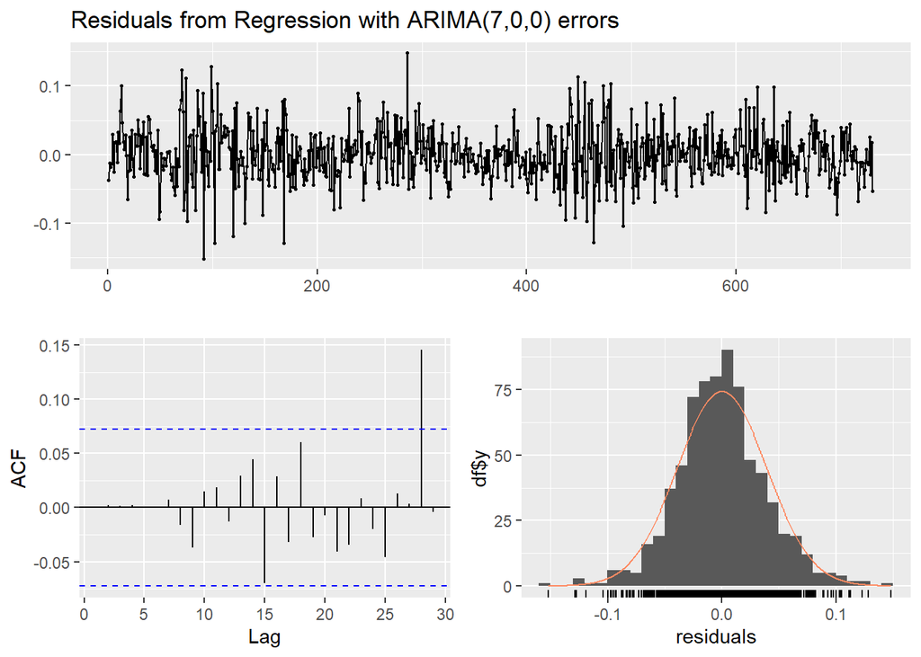

```
    Ljung-Box test

data:  Residuals from Regression with ARIMA(7,0,0) errors
Q* = 1.4048, df = 3, p-value = 0.7044

Model df: 7.   Total lags used: 10
```

```r
checkresiduals(mymod6)
```

```python
# Import functions from packages
from statsmodels.tsa.arima.model import ARIMA

# Prep data
# mydates = tdat["Date"]
# mydates = pd.date_range(start="2018-01-01", end="2019-12-31", freq="D")
# tdat.index = mydates
endog = tdat["CountBL"]
exog = tdat[["Month_Feb", "Month_Mar", "Month_Apr", "Month_May", "Month_Jun",
  "Month_Jul", "Month_Aug", "Month_Sep", "Month_Oct", "Month_Nov", "Month_Dec",
  "Weekday_Tue", "Weekday_Wed", "Weekday_Thu", "Weekday_Fri", "Weekday_Sat", "Weekday_Sun",
  "TMAX90", "TMIN32", "PRCPANY"]]
exog = exog.astype(float)
# exog = exog.dropna()
# endog = endog.loc[exog.index]

# ARIMA model
# mymod6 = ARIMA(tdat["CountBL"], order=(7,0,0)).fit()
mymod6 = ARIMA(endog, order=(7,0,0), exog=exog).fit()
# Inspect
mymod6.summary()
```

```
<class 'statsmodels.iolib.summary.Summary'>
"""
                               SARIMAX Results
==============================================================================
Dep. Variable:                CountBL   No. Observations:                  730
Model:                 ARIMA(7, 0, 0)   Log Likelihood               -3716.576
Date:                Sat, 04 Oct 2025   AIC                           7491.152
Time:                        15:54:20   BIC                           7624.351
Sample:                             0   HQIC                          7542.541
                                - 730
Covariance Type:                  opg
===============================================================================
                  coef    std err          z      P>|z|      [0.025      0.975]
-------------------------------------------------------------------------------
const         160.6794     14.079     11.413      0.000     133.085     188.274
Month_Feb       7.5895     18.015      0.421      0.674     -27.719      42.898
Month_Mar      56.2304     15.694      3.583      0.000      25.470      86.991
Month_Apr      69.3848     15.840      4.380      0.000      38.340     100.430
Month_May      61.8542     17.464      3.542      0.000      27.625      96.083
Month_Jun      69.8099     18.230      3.829      0.000      34.080     105.540
Month_Jul      33.8091     24.257      1.394      0.163     -13.734      81.352
Month_Aug      26.7338     19.218      1.391      0.164     -10.933      64.400
Month_Sep      46.8679     17.842      2.627      0.009      11.899      81.837
Month_Oct      34.4090     18.524      1.857      0.063      -1.898      70.716
Month_Nov      17.1759     18.185      0.945      0.345     -18.466      52.818
Month_Dec     -30.8256     16.627     -1.854      0.064     -63.414       1.763
Weekday_Tue    -0.7673      4.820     -0.159      0.874     -10.214       8.679
Weekday_Wed    -4.6882      5.186     -0.904      0.366     -14.853       5.476
Weekday_Thu   -17.0365      5.763     -2.956      0.003     -28.332      -5.741
Weekday_Fri   -27.0730      5.701     -4.748      0.000     -38.248     -15.898
Weekday_Sat   -38.7265      5.169     -7.492      0.000     -48.858     -28.595
Weekday_Sun   -40.2878      4.620     -8.720      0.000     -49.343     -31.232
TMAX90         -3.8603      8.715     -0.443      0.658     -20.941      13.220
TMIN32        -14.7047      5.441     -2.702      0.007     -25.369      -4.040
PRCPANY       -16.5370      3.466     -4.771      0.000     -23.331      -9.743
ar.L1           0.2644      0.035      7.553      0.000       0.196       0.333
ar.L2           0.1576      0.036      4.423      0.000       0.088       0.227
ar.L3          -0.0103      0.038     -0.269      0.788      -0.085       0.065
ar.L4           0.0755      0.039      1.925      0.054      -0.001       0.152
ar.L5           0.0809      0.039      2.062      0.039       0.004       0.158
ar.L6           0.0279      0.039      0.717      0.474      -0.048       0.104
ar.L7           0.0533      0.035      1.502      0.133      -0.016       0.123
sigma2       1541.6600     73.106     21.088      0.000    1398.376    1684.944
===================================================================================
Ljung-Box (L1) (Q):                   0.00   Jarque-Bera (JB):                29.03
Prob(Q):                              0.98   Prob(JB):                         0.00
Heteroskedasticity (H):               0.62   Skew:                             0.05
Prob(H) (two-sided):                  0.00   Kurtosis:                         3.97
===================================================================================

Warnings:
[1] Covariance matrix calculated using the outer product of gradients (complex-step).
"""
```

```python
plot_acf(mymod6.resid)
plot_pacf(mymod6.resid)
LB3 = acorr_ljungbox(mymod6.resid, lags=[7], return_df=True)
print("Ljung-Box Test Results:")
```

```
Ljung-Box Test Results:
```

```python
print(LB3)
```

```
    lb_stat  lb_pvalue
7  0.056972        1.0
```

[figure not shown]

```python
del LB3
```

## Other tips

If you want to learn more about time series analysis in R, you can check out the following resources:

- The [CRAN Task View on Time Series Analysis](https://cran.r-project.org/web/views/TimeSeries.html) lists all the packages and core functions that you would need to know in order to do pretty much any sort of time series analysis, regression, etc. that you could think of.
- Also, this website seems like a good introduction to time series with R: [Little Book of R for Time Series](https://a-little-book-of-r-for-time-series.readthedocs.io/en/latest/).

*Side note*: There are [CRAN Task Views](https://cran.r-project.org/web/views/) for pretty much every statistical subject. In general, I find CRAN Task Views great if you already know what you are looking for; but, for beginners, the terminology is usually too detailed and confusing.

If you want to learn more about time series analysis in Python, you can check out the following resources:

- [Time series analysis with Python](https://filippomb.github.io/python-time-series-handbook/notebooks/00/intro.html) from Filippo Maria Bianchi.
- [Time Series Analysis & Visualization in Python](https://www.geeksforgeeks.org/data-analysis/time-series-data-visualization-in-python/) from GeeksforGeeks.
- [Complete Guide on Time Series Analysis in Python](https://www.kaggle.com/code/prashant111/complete-guide-on-time-series-analysis-in-python/notebook) from Prashant Banerjee.

## Review

- Can you merge two data frames on a common column?
- Can you create and plot a univariate time series?
- Can you decompose a time series into seasonal, trend, and error components?
- Can you estimate a linear time series regression model?

**END**